# SIS model with no demographics

Moving on from the SI model to something slighlty more complex, we will add a state transition from infected back to susceptible, with no period of immunity - this is the SIS model. It turns out that the equations governing this will be analogous to the SI model with demography - rather than births & mortality providing routes to add susceptibles and subtract infectives, this transition from infective -> susceptible will provide essentially the same mechanism.

$$ \dot{S} = -\frac{\beta*S*I}{N} + \gamma I $$

$$ \dot{I} = \frac{\beta*S*I}{N} - \gamma I $$

As before, subbing $S = N-I$ into the second equation gives us

$$ \dot{I} = \beta I ( 1-\frac{\gamma}{\beta}-\frac{I}{N})$$

And comparing against the SI model with births, it is clear this equation is of the same form, with solution $$ \frac{Nx}{1+(\frac{Nx}{I_0}-1)e^{-\beta x t}} $$

$$ x = (1-\frac{\gamma}{\beta}) $$

This notebook tests the implementation and behavior of the model as follows:

## Construct the model

In the first few cells, we do all the necessary imports. Then we construct a single-patch LASER model with three components: `Susceptibility`, `Transmission`, and `Infection_SIS` - this component will require a new agent property `itimer`, and upon expiration of `itimer` agents will return to the susceptible state. Finally, we initialize with a single infection and run. The `Susceptibility` and `Transmission` components are previously described.

## Sanity check

The first test ensures certain basic constraints are being obeyed by the model. We confirm that at each timestep, $S_t=N_t-I_t$.

## Scientific test

Finally, we come to the scientific test. As before, we first test on a single instance of the model and show that the expected output is recovered. Then, we select a few values of $\beta$ and $\gamma$, run the model, fit the outputs to the logistic equation, and compare the fitted value of $\beta$ and $\gamma$ to the known values; all of the considerations noted in the SI with births model, in terms of how to approach this fit, are echoed again here. Of particular concern is the approximation of an exponential transition from infected back to susceptible - as we are doing a first-order finite timestep integration here, that approximation will probably produce an error linear in $\gamma \Delta t$ between the analytic result and the modeled result. In fact, in a lot of real disease models, we have compartment dwell times in the exposed and infective states that are only a handful of $\Delta t$ long, but when doing real epi modeling and calibrating model parameters to uncertain data, this is generally not likely to be a dominant source of bias, uncertainty, etc. But when comparing specifically against an analytic result, it can become significant.

```python
import matplotlib.pyplot as plt
import numba as nb
import numpy as np
import pandas as pd
from laser.core.propertyset import PropertySet
from scipy.optimize import curve_fit
from scipy.optimize import minimize

import laser.core
import laser.generic

print(f"{np.__version__=}")
print(f"{laser.core.__version__=}")
print(f"{laser.generic.__version__=}")
```

import matplotlib.pyplot as plt import numba as nb import numpy as np import pandas as pd from laser.core.propertyset import PropertySet from scipy.optimize import curve_fit from scipy.optimize import minimize import laser.core import laser.generic print(f"{np.__version__=}") print(f"{laser.core.__version__=}") print(f"{laser.generic.__version__=}")

```
np.__version__='2.4.6'
laser.core.__version__='1.0.5'
laser.generic.__version__='1.1.0'
```

```python
import laser.core.distributions as dists
import laser.generic.SIS as SIS
from laser.generic import Model
from laser.core.utils import grid
```

import laser.core.distributions as dists import laser.generic.SIS as SIS from laser.generic import Model from laser.core.utils import grid

To make sure we don't accumulate lots of finite time-step error, make inf mean quite long in units of timestep

```python
pop = 3e5

scenario = grid(M=1, N=1, population_fn=lambda x,y: pop, origin_x=0, origin_y=0)
initial_infected = 1
scenario["S"] = scenario.population - initial_infected
scenario["I"] = initial_infected
parameters = PropertySet({"prng_seed": 42, "nticks": 3000, "beta": 0.1, "inf_mean": 32})

infdurdist = dists.exponential(scale=parameters.inf_mean)
```

pop = 3e5 scenario = grid(M=1, N=1, population_fn=lambda x,y: pop, origin_x=0, origin_y=0) initial_infected = 1 scenario["S"] = scenario.population - initial_infected scenario["I"] = initial_infected parameters = PropertySet({"prng_seed": 42, "nticks": 3000, "beta": 0.1, "inf_mean": 32}) infdurdist = dists.exponential(scale=parameters.inf_mean)

```python
# Run until we get an outbreak
outbreak = False
while not outbreak:
    parameters.prng_seed += 1
    model = Model(scenario, parameters)

    model.components = [SIS.Susceptible(model), SIS.Infectious(model, infdurdist), SIS.Transmission(model, infdurdist)]

    model.run()
    outbreak = np.any(model.nodes.I[200] > 0)
```

# Run until we get an outbreak outbreak = False while not outbreak: parameters.prng_seed += 1 model = Model(scenario, parameters) model.components = [SIS.Susceptible(model), SIS.Infectious(model, infdurdist), SIS.Transmission(model, infdurdist)] model.run() outbreak = np.any(model.nodes.I[200] > 0)

## Sanity checks

Check that the relationships between susceptible, infected, and total population hold.

```python
fig, axs = plt.subplots(1, 2, figsize=(18, 5))

# Panel 2: Susceptible over time
axs[0].plot(model.nodes.S[1:], lw=4)
axs[0].plot(model.nodes.S[:-1] + model.nodes.newly_recovered[:-1] - model.nodes.newly_infected[:-1])
axs[0].set_yscale("log")
axs[0].set_title("Susceptible over time")
axs[0].set_xlabel("Time")
axs[0].set_ylabel("Susceptible")

# Panel 3: Population minus cumulative infections (incidence)
axs[1].plot(model.nodes.I[1:], lw=4)
axs[1].plot(model.nodes.I[:-1] - model.nodes.newly_recovered[:-1] + model.nodes.newly_infected[:-1])
axs[1].set_yscale("log")
axs[1].set_title("Population minus cumulative infections")
axs[1].set_xlabel("Time")
axs[1].set_ylabel("Incidence")

plt.tight_layout()

print("S[t] = S[t-1] + recovered[t-1] - incidence[t-1]: ", np.allclose(model.nodes.S[1:], model.nodes.S[:-1] + model.nodes.newly_recovered[:-1] - model.nodes.newly_infected[:-1]))
print("I[t] = I[t-1] - recovered[t-1] + incidence[t-1]: ", np.allclose(model.nodes.I[1:], model.nodes.I[:-1] - model.nodes.newly_recovered[:-1] + model.nodes.newly_infected[:-1]))
```

fig, axs = plt.subplots(1, 2, figsize=(18, 5)) # Panel 2: Susceptible over time axs[0].plot(model.nodes.S[1:], lw=4) axs[0].plot(model.nodes.S[:-1] + model.nodes.newly_recovered[:-1] - model.nodes.newly_infected[:-1]) axs[0].set_yscale("log") axs[0].set_title("Susceptible over time") axs[0].set_xlabel("Time") axs[0].set_ylabel("Susceptible") # Panel 3: Population minus cumulative infections (incidence) axs[1].plot(model.nodes.I[1:], lw=4) axs[1].plot(model.nodes.I[:-1] - model.nodes.newly_recovered[:-1] + model.nodes.newly_infected[:-1]) axs[1].set_yscale("log") axs[1].set_title("Population minus cumulative infections") axs[1].set_xlabel("Time") axs[1].set_ylabel("Incidence") plt.tight_layout() print("S[t] = S[t-1] + recovered[t-1] - incidence[t-1]: ", np.allclose(model.nodes.S[1:], model.nodes.S[:-1] + model.nodes.newly_recovered[:-1] - model.nodes.newly_infected[:-1])) print("I[t] = I[t-1] - recovered[t-1] + incidence[t-1]: ", np.allclose(model.nodes.I[1:], model.nodes.I[:-1] - model.nodes.newly_recovered[:-1] + model.nodes.newly_infected[:-1]))

```
S[t] = S[t-1] + recovered[t-1] - incidence[t-1]:  True
I[t] = I[t-1] - recovered[t-1] + incidence[t-1]:  True
```

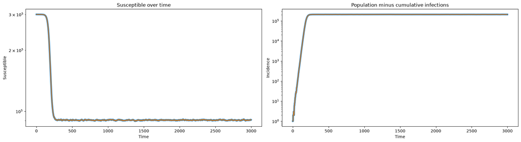

### Single-simulation check

As before, starting with a single infection induces some stochasticity in terms of when the outbreak really starts to take off, and so we fit the expected behavior with a free offset parameter below.

```python
def SIS_logistic(t, beta, popsize, gamma, t0):
    x = 1 - gamma / beta
    return popsize * x / (1 + (popsize * x - 1) * np.exp(-beta * x * (t - t0)))


t = np.arange(model.params.nticks+1)


def objective(t0):
    return np.sum(
        (1 - SIS_logistic(t, model.params.beta, pop, 1 / model.params.inf_mean, t0) / np.squeeze(model.nodes.I)) ** 2
    )


result = minimize(objective, x0=10)
t0_opt = result.x[0]

plt.plot(model.nodes.I, lw=4)
plt.plot(SIS_logistic(t, model.params.beta, pop, 1 / model.params.inf_mean, 0), lw=3)
plt.plot(SIS_logistic(t, model.params.beta, pop, 1 / model.params.inf_mean, t0_opt), "r:", lw=3)
plt.yscale("log")
plt.legend(["Model output", "Logistic growth with known inputs, t0=0", f"Logistic growth with known inputs, best-fit t0 = {t0_opt:.1f}"])
```

def SIS_logistic(t, beta, popsize, gamma, t0): x = 1 - gamma / beta return popsize * x / (1 + (popsize * x - 1) * np.exp(-beta * x * (t - t0))) t = np.arange(model.params.nticks+1) def objective(t0): return np.sum( (1 - SIS_logistic(t, model.params.beta, pop, 1 / model.params.inf_mean, t0) / np.squeeze(model.nodes.I)) ** 2 ) result = minimize(objective, x0=10) t0_opt = result.x[0] plt.plot(model.nodes.I, lw=4) plt.plot(SIS_logistic(t, model.params.beta, pop, 1 / model.params.inf_mean, 0), lw=3) plt.plot(SIS_logistic(t, model.params.beta, pop, 1 / model.params.inf_mean, t0_opt), "r:", lw=3) plt.yscale("log") plt.legend(["Model output", "Logistic growth with known inputs, t0=0", f"Logistic growth with known inputs, best-fit t0 = {t0_opt:.1f}"])

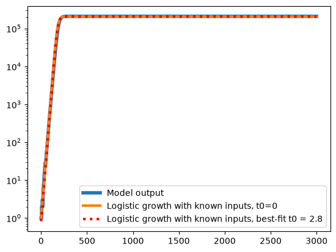

## Scientific testing

Finally, we run the model for a range of $\beta$ & $\gamma$ parameters, we freely fit the model output to the logistic equation, and we compare the known input parameters against the parameters fitted from output.

```python
NTESTS = 10
nticks = 730
t = np.arange(nticks)
betarange = [0.02, 0.1]
gammarange = [1 / 300, 1 / 100]
seeds = list(range(NTESTS))
pop = 1e5
betas = np.random.uniform(betarange[0], betarange[1], NTESTS)
gammas = np.random.uniform(gammarange[0], gammarange[1], NTESTS)
scenario = grid(M=1, N=1, population_fn=lambda x,y: pop, origin_x=0, origin_y=0)
initial_infected = 3
scenario["S"] = scenario.population - initial_infected
scenario["I"] = initial_infected

output = []
for i, (seed, beta, gamma) in enumerate(zip(seeds, betas, gammas)):
    parameters = PropertySet({"prng_seed": seed, "nticks": nticks, "verbose": True, "beta": beta, "inf_mean": 1 / gamma})

    model = Model(scenario, parameters)

    infdurdist = dists.exponential(scale=parameters.inf_mean)

    model.components = [SIS.Susceptible(model), SIS.Infectious(model, infdurdist), SIS.Transmission(model, infdurdist)]

    model.run(label=f"SIS {i+1:2} of {NTESTS}, seed={seed}, beta={beta:.3f}, gamma={gamma:.5f}")
    cases = model.nodes.I[1:,0]
    popt, pcov = curve_fit(
        SIS_logistic,
        t,
        cases,
        p0=[np.mean(betarange), pop, np.mean(gammarange), 1],
        bounds=([betarange[0] / 2, pop - 1, gammarange[0] / 2, -300], [betarange[1] * 2, pop + 1, gammarange[1] * 2, 300]),
    )

    output.append(
        {
            "seed": seed,
            "beta": beta,
            "gamma": gamma,
            "cases": [np.array(cases)],
            "fitted_beta": popt[0],
            "fitted_gamma": popt[2],
            "fitted_t0": popt[3],
            "recovered": [np.array(model.nodes.newly_recovered[1:,0])]
        }
    )

output = pd.DataFrame(output)
```

NTESTS = 10 nticks = 730 t = np.arange(nticks) betarange = [0.02, 0.1] gammarange = [1 / 300, 1 / 100] seeds = list(range(NTESTS)) pop = 1e5 betas = np.random.uniform(betarange[0], betarange[1], NTESTS) gammas = np.random.uniform(gammarange[0], gammarange[1], NTESTS) scenario = grid(M=1, N=1, population_fn=lambda x,y: pop, origin_x=0, origin_y=0) initial_infected = 3 scenario["S"] = scenario.population - initial_infected scenario["I"] = initial_infected output = [] for i, (seed, beta, gamma) in enumerate(zip(seeds, betas, gammas)): parameters = PropertySet({"prng_seed": seed, "nticks": nticks, "verbose": True, "beta": beta, "inf_mean": 1 / gamma}) model = Model(scenario, parameters) infdurdist = dists.exponential(scale=parameters.inf_mean) model.components = [SIS.Susceptible(model), SIS.Infectious(model, infdurdist), SIS.Transmission(model, infdurdist)] model.run(label=f"SIS {i+1:2} of {NTESTS}, seed={seed}, beta={beta:.3f}, gamma={gamma:.5f}") cases = model.nodes.I[1:,0] popt, pcov = curve_fit( SIS_logistic, t, cases, p0=[np.mean(betarange), pop, np.mean(gammarange), 1], bounds=([betarange[0] / 2, pop - 1, gammarange[0] / 2, -300], [betarange[1] * 2, pop + 1, gammarange[1] * 2, 300]), ) output.append( { "seed": seed, "beta": beta, "gamma": gamma, "cases": [np.array(cases)], "fitted_beta": popt[0], "fitted_gamma": popt[2], "fitted_t0": popt[3], "recovered": [np.array(model.nodes.newly_recovered[1:,0])] } ) output = pd.DataFrame(output)

```
SIS  1 of 10, seed=0, beta=0.030, gamma=0.00478:   0%|          | 0/730 [00:00<?, ?it/s]
```

```
SIS  1 of 10, seed=0, beta=0.030, gamma=0.00478:   0%|          | 1/730 [00:00<06:11,  1.96it/s]
```

```
SIS  1 of 10, seed=0, beta=0.030, gamma=0.00478:  22%|██▏       | 159/730 [00:00<00:01, 347.66it/s]
```

```
SIS  1 of 10, seed=0, beta=0.030, gamma=0.00478:  43%|████▎     | 317/730 [00:00<00:00, 640.75it/s]
```

```
SIS  1 of 10, seed=0, beta=0.030, gamma=0.00478:  65%|██████▍   | 472/730 [00:00<00:00, 870.38it/s]
```

```
SIS  1 of 10, seed=0, beta=0.030, gamma=0.00478:  94%|█████████▍| 687/730 [00:00<00:00, 1209.83it/s]
```

```
SIS  1 of 10, seed=0, beta=0.030, gamma=0.00478: 100%|██████████| 730/730 [00:00<00:00, 786.01it/s]
```

```
SIS  2 of 10, seed=1, beta=0.066, gamma=0.00870:   0%|          | 0/730 [00:00<?, ?it/s]
```

```
SIS  2 of 10, seed=1, beta=0.066, gamma=0.00870:   0%|          | 1/730 [00:00<06:01,  2.02it/s]
```

```
SIS  2 of 10, seed=1, beta=0.066, gamma=0.00870:  19%|█▉        | 137/730 [00:00<00:01, 305.51it/s]
```

```
SIS  2 of 10, seed=1, beta=0.066, gamma=0.00870:  48%|████▊     | 347/730 [00:00<00:00, 739.36it/s]
```

```
SIS  2 of 10, seed=1, beta=0.066, gamma=0.00870:  89%|████████▉ | 648/730 [00:00<00:00, 1321.87it/s]
```

```
SIS  2 of 10, seed=1, beta=0.066, gamma=0.00870: 100%|██████████| 730/730 [00:00<00:00, 883.15it/s]
```

```
SIS  3 of 10, seed=2, beta=0.089, gamma=0.00488:   0%|          | 0/730 [00:00<?, ?it/s]
```

```
SIS  3 of 10, seed=2, beta=0.089, gamma=0.00488:   0%|          | 1/730 [00:00<06:02,  2.01it/s]
```

```
SIS  3 of 10, seed=2, beta=0.089, gamma=0.00488:  22%|██▏       | 164/730 [00:00<00:01, 365.64it/s]
```

```
SIS  3 of 10, seed=2, beta=0.089, gamma=0.00488:  75%|███████▌  | 550/730 [00:00<00:00, 1210.37it/s]
```

```
SIS  3 of 10, seed=2, beta=0.089, gamma=0.00488: 100%|██████████| 730/730 [00:00<00:00, 981.15it/s]
```

```
SIS  4 of 10, seed=3, beta=0.068, gamma=0.00471:   0%|          | 0/730 [00:00<?, ?it/s]
```

```
SIS  4 of 10, seed=3, beta=0.068, gamma=0.00471:   0%|          | 1/730 [00:00<05:59,  2.03it/s]
```

```
SIS  4 of 10, seed=3, beta=0.068, gamma=0.00471:  21%|██        | 154/730 [00:00<00:01, 345.04it/s]
```

```
SIS  4 of 10, seed=3, beta=0.068, gamma=0.00471:  64%|██████▎   | 464/730 [00:00<00:00, 1013.53it/s]
```

```
SIS  4 of 10, seed=3, beta=0.068, gamma=0.00471: 100%|██████████| 730/730 [00:00<00:00, 953.75it/s]
```

```
SIS  5 of 10, seed=4, beta=0.064, gamma=0.00768:   0%|          | 0/730 [00:00<?, ?it/s]
```

```
SIS  5 of 10, seed=4, beta=0.064, gamma=0.00768:   0%|          | 1/730 [00:00<06:08,  1.98it/s]
```

```
SIS  5 of 10, seed=4, beta=0.064, gamma=0.00768:  22%|██▏       | 159/730 [00:00<00:01, 349.05it/s]
```

```
SIS  5 of 10, seed=4, beta=0.064, gamma=0.00768:  58%|█████▊    | 420/730 [00:00<00:00, 889.33it/s]
```

```
SIS  5 of 10, seed=4, beta=0.064, gamma=0.00768: 100%|██████████| 730/730 [00:00<00:00, 906.01it/s]
```

```
SIS  6 of 10, seed=5, beta=0.050, gamma=0.00816:   0%|          | 0/730 [00:00<?, ?it/s]
```

```
SIS  6 of 10, seed=5, beta=0.050, gamma=0.00816:   0%|          | 1/730 [00:00<06:07,  1.98it/s]
```

```
SIS  6 of 10, seed=5, beta=0.050, gamma=0.00816:  22%|██▏       | 159/730 [00:00<00:01, 350.02it/s]
```

```
SIS  6 of 10, seed=5, beta=0.050, gamma=0.00816:  46%|████▋     | 339/730 [00:00<00:00, 697.28it/s]
```

```
SIS  6 of 10, seed=5, beta=0.050, gamma=0.00816:  85%|████████▍ | 618/730 [00:00<00:00, 1230.79it/s]
```

```
SIS  6 of 10, seed=5, beta=0.050, gamma=0.00816: 100%|██████████| 730/730 [00:00<00:00, 862.69it/s]
```

```
SIS  7 of 10, seed=6, beta=0.100, gamma=0.00864:   0%|          | 0/730 [00:00<?, ?it/s]
```

```
SIS  7 of 10, seed=6, beta=0.100, gamma=0.00864:   0%|          | 1/730 [00:00<06:02,  2.01it/s]
```

```
SIS  7 of 10, seed=6, beta=0.100, gamma=0.00864:  25%|██▍       | 180/730 [00:00<00:01, 400.74it/s]
```

```
SIS  7 of 10, seed=6, beta=0.100, gamma=0.00864:  70%|███████   | 513/730 [00:00<00:00, 1107.93it/s]
```

```
SIS  7 of 10, seed=6, beta=0.100, gamma=0.00864: 100%|██████████| 730/730 [00:00<00:00, 956.88it/s]
```

```
SIS  8 of 10, seed=7, beta=0.081, gamma=0.00601:   0%|          | 0/730 [00:00<?, ?it/s]
```

```
SIS  8 of 10, seed=7, beta=0.081, gamma=0.00601:   0%|          | 1/730 [00:00<06:03,  2.01it/s]
```

```
SIS  8 of 10, seed=7, beta=0.081, gamma=0.00601:  22%|██▏       | 158/730 [00:00<00:01, 351.44it/s]
```

```
SIS  8 of 10, seed=7, beta=0.081, gamma=0.00601:  69%|██████▉   | 506/730 [00:00<00:00, 1106.39it/s]
```

```
SIS  8 of 10, seed=7, beta=0.081, gamma=0.00601: 100%|██████████| 730/730 [00:00<00:00, 958.46it/s]
```

```
SIS  9 of 10, seed=8, beta=0.086, gamma=0.00476:   0%|          | 0/730 [00:00<?, ?it/s]
```

```
SIS  9 of 10, seed=8, beta=0.086, gamma=0.00476:   0%|          | 1/730 [00:00<06:11,  1.96it/s]
```

```
SIS  9 of 10, seed=8, beta=0.086, gamma=0.00476:  22%|██▏       | 157/730 [00:00<00:01, 343.01it/s]
```

```
SIS  9 of 10, seed=8, beta=0.086, gamma=0.00476:  73%|███████▎  | 536/730 [00:00<00:00, 1163.72it/s]
```

```
SIS  9 of 10, seed=8, beta=0.086, gamma=0.00476: 100%|██████████| 730/730 [00:00<00:00, 959.37it/s]
```

```
SIS 10 of 10, seed=9, beta=0.080, gamma=0.00903:   0%|          | 0/730 [00:00<?, ?it/s]
```

```
SIS 10 of 10, seed=9, beta=0.080, gamma=0.00903:   0%|          | 1/730 [00:00<06:07,  1.99it/s]
```

```
SIS 10 of 10, seed=9, beta=0.080, gamma=0.00903:  21%|██        | 155/730 [00:00<00:01, 341.65it/s]
```

```
SIS 10 of 10, seed=9, beta=0.080, gamma=0.00903:  58%|█████▊    | 421/730 [00:00<00:00, 897.37it/s]
```

```
SIS 10 of 10, seed=9, beta=0.080, gamma=0.00903: 100%|██████████| 730/730 [00:00<00:00, 910.02it/s]
```

```python
plt.figure()
plt.plot(output["beta"], output["fitted_beta"], "o")
plt.xlim(betarange[0], betarange[1])
plt.ylim(betarange[0], betarange[1])
plt.figure()
plt.plot(output["beta"], 1 - output["beta"] / output["fitted_beta"], "o")
plt.xlim(betarange[0], betarange[1])
plt.ylim(-0.25, 0.25)
plt.figure()
plt.plot(output["gamma"], output["fitted_gamma"], "o")
plt.xlim(gammarange[0]*0.9, gammarange[1]*1.1)
plt.ylim(gammarange[0]*0.9, gammarange[1]*1.1)
plt.figure()
plt.plot(output["gamma"], 1 - output["gamma"] / output["fitted_gamma"], "o")
plt.xlim(gammarange[0]*0.9, gammarange[1]*1.1)
plt.ylim(-0.25, 0.25)
```

plt.figure() plt.plot(output["beta"], output["fitted_beta"], "o") plt.xlim(betarange[0], betarange[1]) plt.ylim(betarange[0], betarange[1]) plt.figure() plt.plot(output["beta"], 1 - output["beta"] / output["fitted_beta"], "o") plt.xlim(betarange[0], betarange[1]) plt.ylim(-0.25, 0.25) plt.figure() plt.plot(output["gamma"], output["fitted_gamma"], "o") plt.xlim(gammarange[0]*0.9, gammarange[1]*1.1) plt.ylim(gammarange[0]*0.9, gammarange[1]*1.1) plt.figure() plt.plot(output["gamma"], 1 - output["gamma"] / output["fitted_gamma"], "o") plt.xlim(gammarange[0]*0.9, gammarange[1]*1.1) plt.ylim(-0.25, 0.25)

```
(-0.25, 0.25)
```

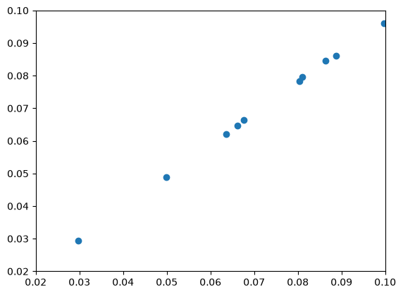

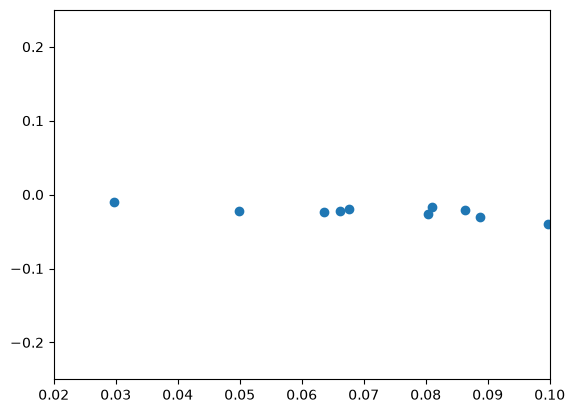

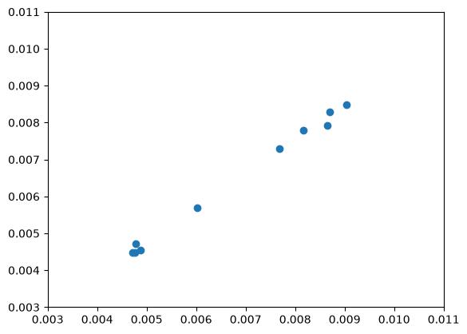

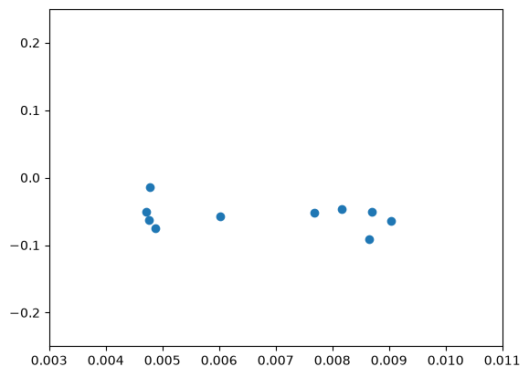

```python
print(
    "All fitted beta are within 10% of known beta: " + str(np.all(np.abs((output["beta"] - output["fitted_beta"]) / output["beta"]) < 0.10))
)
print(
    "All fitted gamma are within 20% of known gamma: "
    + str(np.all(np.abs((output["gamma"] - output["fitted_gamma"]) / output["gamma"]) < 0.20))
)
```

print( "All fitted beta are within 10% of known beta: " + str(np.all(np.abs((output["beta"] - output["fitted_beta"]) / output["beta"]) < 0.10)) ) print( "All fitted gamma are within 20% of known gamma: " + str(np.all(np.abs((output["gamma"] - output["fitted_gamma"]) / output["gamma"]) < 0.20)) )

```
All fitted beta are within 10% of known beta: True
All fitted gamma are within 20% of known gamma: True
```

```python
output
```

output

|  | seed | beta | gamma | cases | fitted_beta | fitted_gamma | fitted_t0 | recovered |
| --- | --- | --- | --- | --- | --- | --- | --- | --- |
| 0 | 0 | 0.029660 | 0.004783 | [[3, 3, 3, 3, 3, 3, 3, 3, 3, 3, 3, 3, 3, 3, 3,... | 0.029368 | 0.004720 | 20.838835 | [[0, 0, 0, 0, 0, 0, 0, 0, 0, 0, 0, 0, 0, 0, 0,... |
| 1 | 1 | 0.066200 | 0.008704 | [[3, 3, 4, 4, 4, 4, 4, 4, 4, 4, 4, 4, 4, 4, 4,... | 0.064756 | 0.008288 | -4.290726 | [[0, 0, 0, 0, 0, 0, 0, 0, 0, 0, 0, 0, 0, 0, 0,... |
| 2 | 2 | 0.088750 | 0.004881 | [[3, 3, 4, 5, 5, 5, 5, 5, 5, 5, 5, 5, 5, 5, 5,... | 0.086093 | 0.004543 | -10.462367 | [[0, 0, 0, 0, 0, 0, 0, 0, 0, 0, 0, 0, 0, 0, 0,... |
| 3 | 3 | 0.067663 | 0.004713 | [[3, 3, 4, 5, 5, 6, 6, 6, 6, 6, 6, 6, 6, 6, 6,... | 0.066388 | 0.004484 | -14.267791 | [[0, 0, 0, 0, 0, 0, 0, 0, 0, 0, 0, 0, 0, 0, 0,... |
| 4 | 4 | 0.063574 | 0.007682 | [[3, 3, 5, 7, 7, 10, 10, 10, 10, 10, 10, 11, 1... | 0.062098 | 0.007300 | -32.528845 | [[0, 0, 0, 0, 0, 0, 0, 0, 0, 0, 0, 0, 0, 0, 0,... |
| 5 | 5 | 0.049859 | 0.008158 | [[3, 3, 4, 6, 6, 7, 7, 7, 6, 6, 6, 7, 7, 9, 10... | 0.048783 | 0.007794 | -44.728408 | [[0, 0, 0, 0, 0, 0, 0, 1, 0, 0, 0, 0, 0, 0, 0,... |
| 6 | 6 | 0.099783 | 0.008644 | [[3, 4, 5, 6, 6, 8, 8, 9, 8, 8, 8, 11, 11, 13,... | 0.096004 | 0.007926 | -16.705762 | [[0, 0, 0, 0, 0, 0, 0, 1, 0, 0, 0, 0, 0, 0, 0,... |
| 7 | 7 | 0.080933 | 0.006014 | [[2, 2, 3, 4, 4, 5, 5, 5, 5, 5, 5, 7, 6, 10, 1... | 0.079572 | 0.005687 | -15.736388 | [[0, 0, 0, 0, 0, 0, 0, 0, 0, 0, 0, 1, 0, 0, 0,... |
| 8 | 8 | 0.086307 | 0.004760 | [[3, 3, 3, 3, 3, 3, 3, 3, 3, 3, 3, 4, 4, 7, 7,... | 0.084583 | 0.004480 | -7.118933 | [[1, 0, 0, 0, 0, 0, 0, 0, 0, 0, 0, 0, 0, 0, 0,... |
| 9 | 9 | 0.080437 | 0.009030 | [[2, 2, 2, 2, 2, 2, 2, 2, 2, 2, 2, 2, 2, 3, 3,... | 0.078388 | 0.008481 | 7.971066 | [[0, 0, 0, 0, 0, 0, 0, 0, 0, 0, 0, 0, 0, 0, 0,... |

### Quick demonstration of first-order error accumulation

As noted before, for $\gamma \Delta t$ large, first-order integration like we are doing here can accumulate substantial error. Calculating exactly how error will accumulate in an integrator for a dynamic process like this is beyond the scope here, and probably depends on a lot of details. E.g., the ordering of steps - in a given step, does the `transmission` update from S->I state occur before or after the `infection` update that sends agents from I->S? Do we use midpoint methods, timer countdowns, or take advantage of the unique memorylessness of the exponential distribution to simply remove a random fraction each time? All that is beyond scope here, but just want to demonstrate that the error in the equilibrium value $I(t \rightarrow \infty)$ becomes large when the mean infectious period $\frac{1}{\gamma}$ is on the same order as $\Delta t$

```python
# %%capture

gammas = [1 / infmean for infmean in [1, 1.5, 2, 2.5, 3, 6, 12, 18, 30, 45, 60, 90, 120, 180, 240, 300]]
betas = [3 * gamma for gamma in gammas]

NTESTS = len(gammas)
nticks = 3000
seeds = list(range(NTESTS))
pop = 1e5
final_expected = np.array([])
final_observed = np.array([])
scenario = grid(M=1, N=1, population_fn=lambda x,y: pop, origin_x=0, origin_y=0)
initial_infected = 20
scenario["S"] = scenario.population - initial_infected
scenario["I"] = initial_infected

for i, (seed, beta, gamma) in enumerate(zip(seeds, betas, gammas)):
    parameters = PropertySet({"prng_seed": seed, "nticks": nticks, "verbose": True, "beta": beta, "inf_mean": 1 / gamma})

    model = Model(scenario, parameters)

    infdurdist = dists.exponential(scale=parameters.inf_mean)

    model.components = [SIS.Susceptible(model), SIS.Infectious(model, infdurdist), SIS.Transmission(model, infdurdist)]

    model.run(label=f"SIS {i+1:2} of {NTESTS}, seed={seed:2}, beta={beta:.3f}, gamma={gamma:.5f}")
    final_observed = np.append(final_observed, model.nodes.I[-1,0])
    final_expected = np.append(final_expected, pop * (1 - gamma / beta))
```

# %%capture gammas = [1 / infmean for infmean in [1, 1.5, 2, 2.5, 3, 6, 12, 18, 30, 45, 60, 90, 120, 180, 240, 300]] betas = [3 * gamma for gamma in gammas] NTESTS = len(gammas) nticks = 3000 seeds = list(range(NTESTS)) pop = 1e5 final_expected = np.array([]) final_observed = np.array([]) scenario = grid(M=1, N=1, population_fn=lambda x,y: pop, origin_x=0, origin_y=0) initial_infected = 20 scenario["S"] = scenario.population - initial_infected scenario["I"] = initial_infected for i, (seed, beta, gamma) in enumerate(zip(seeds, betas, gammas)): parameters = PropertySet({"prng_seed": seed, "nticks": nticks, "verbose": True, "beta": beta, "inf_mean": 1 / gamma}) model = Model(scenario, parameters) infdurdist = dists.exponential(scale=parameters.inf_mean) model.components = [SIS.Susceptible(model), SIS.Infectious(model, infdurdist), SIS.Transmission(model, infdurdist)] model.run(label=f"SIS {i+1:2} of {NTESTS}, seed={seed:2}, beta={beta:.3f}, gamma={gamma:.5f}") final_observed = np.append(final_observed, model.nodes.I[-1,0]) final_expected = np.append(final_expected, pop * (1 - gamma / beta))

```
SIS  1 of 16, seed= 0, beta=3.000, gamma=1.00000:   0%|          | 0/3000 [00:00<?, ?it/s]
```

```
SIS  1 of 16, seed= 0, beta=3.000, gamma=1.00000:   0%|          | 1/3000 [00:00<35:23,  1.41it/s]
```

```
SIS  1 of 16, seed= 0, beta=3.000, gamma=1.00000:   2%|▏         | 53/3000 [00:00<00:33, 88.29it/s]
```

```
SIS  1 of 16, seed= 0, beta=3.000, gamma=1.00000:   3%|▎         | 102/3000 [00:00<00:17, 165.31it/s]
```

```
SIS  1 of 16, seed= 0, beta=3.000, gamma=1.00000:   5%|▌         | 150/3000 [00:01<00:12, 233.08it/s]
```

```
SIS  1 of 16, seed= 0, beta=3.000, gamma=1.00000:   7%|▋         | 197/3000 [00:01<00:09, 288.52it/s]
```

```
SIS  1 of 16, seed= 0, beta=3.000, gamma=1.00000:   8%|▊         | 245/3000 [00:01<00:08, 336.64it/s]
```

```
SIS  1 of 16, seed= 0, beta=3.000, gamma=1.00000:  10%|▉         | 294/3000 [00:01<00:07, 375.79it/s]
```

```
SIS  1 of 16, seed= 0, beta=3.000, gamma=1.00000:  11%|█▏        | 341/3000 [00:01<00:06, 396.58it/s]
```

```
SIS  1 of 16, seed= 0, beta=3.000, gamma=1.00000:  13%|█▎        | 390/3000 [00:01<00:06, 420.81it/s]
```

```
SIS  1 of 16, seed= 0, beta=3.000, gamma=1.00000:  15%|█▍        | 438/3000 [00:01<00:05, 436.54it/s]
```

```
SIS  1 of 16, seed= 0, beta=3.000, gamma=1.00000:  16%|█▌        | 487/3000 [00:01<00:05, 449.48it/s]
```

```
SIS  1 of 16, seed= 0, beta=3.000, gamma=1.00000:  18%|█▊        | 536/3000 [00:01<00:05, 458.60it/s]
```

```
SIS  1 of 16, seed= 0, beta=3.000, gamma=1.00000:  20%|█▉        | 585/3000 [00:01<00:05, 465.59it/s]
```

```
SIS  1 of 16, seed= 0, beta=3.000, gamma=1.00000:  21%|██        | 633/3000 [00:02<00:05, 469.36it/s]
```

```
SIS  1 of 16, seed= 0, beta=3.000, gamma=1.00000:  23%|██▎       | 681/3000 [00:02<00:04, 471.70it/s]
```

```
SIS  1 of 16, seed= 0, beta=3.000, gamma=1.00000:  24%|██▍       | 730/3000 [00:02<00:04, 474.54it/s]
```

```
SIS  1 of 16, seed= 0, beta=3.000, gamma=1.00000:  26%|██▌       | 778/3000 [00:02<00:04, 474.30it/s]
```

```
SIS  1 of 16, seed= 0, beta=3.000, gamma=1.00000:  28%|██▊       | 827/3000 [00:02<00:04, 476.14it/s]
```

```
SIS  1 of 16, seed= 0, beta=3.000, gamma=1.00000:  29%|██▉       | 876/3000 [00:02<00:04, 478.08it/s]
```

```
SIS  1 of 16, seed= 0, beta=3.000, gamma=1.00000:  31%|███       | 925/3000 [00:02<00:04, 479.36it/s]
```

```
SIS  1 of 16, seed= 0, beta=3.000, gamma=1.00000:  32%|███▏      | 974/3000 [00:02<00:04, 478.81it/s]
```

```
SIS  1 of 16, seed= 0, beta=3.000, gamma=1.00000:  34%|███▍      | 1022/3000 [00:02<00:04, 478.85it/s]
```

```
SIS  1 of 16, seed= 0, beta=3.000, gamma=1.00000:  36%|███▌      | 1070/3000 [00:02<00:04, 478.59it/s]
```

```
SIS  1 of 16, seed= 0, beta=3.000, gamma=1.00000:  37%|███▋      | 1118/3000 [00:03<00:03, 477.50it/s]
```

```
SIS  1 of 16, seed= 0, beta=3.000, gamma=1.00000:  39%|███▉      | 1166/3000 [00:03<00:04, 436.84it/s]
```

```
SIS  1 of 16, seed= 0, beta=3.000, gamma=1.00000:  40%|████      | 1211/3000 [00:03<00:04, 437.53it/s]
```

```
SIS  1 of 16, seed= 0, beta=3.000, gamma=1.00000:  42%|████▏     | 1257/3000 [00:03<00:03, 443.20it/s]
```

```
SIS  1 of 16, seed= 0, beta=3.000, gamma=1.00000:  43%|████▎     | 1303/3000 [00:03<00:03, 445.94it/s]
```

```
SIS  1 of 16, seed= 0, beta=3.000, gamma=1.00000:  45%|████▍     | 1349/3000 [00:03<00:03, 448.95it/s]
```

```
SIS  1 of 16, seed= 0, beta=3.000, gamma=1.00000:  46%|████▋     | 1395/3000 [00:03<00:03, 450.23it/s]
```

```
SIS  1 of 16, seed= 0, beta=3.000, gamma=1.00000:  48%|████▊     | 1441/3000 [00:03<00:03, 449.72it/s]
```

```
SIS  1 of 16, seed= 0, beta=3.000, gamma=1.00000:  50%|████▉     | 1487/3000 [00:03<00:03, 450.57it/s]
```

```
SIS  1 of 16, seed= 0, beta=3.000, gamma=1.00000:  51%|█████     | 1533/3000 [00:03<00:03, 450.97it/s]
```

```
SIS  1 of 16, seed= 0, beta=3.000, gamma=1.00000:  53%|█████▎    | 1579/3000 [00:04<00:03, 450.98it/s]
```

```
SIS  1 of 16, seed= 0, beta=3.000, gamma=1.00000:  54%|█████▍    | 1625/3000 [00:04<00:03, 453.52it/s]
```

```
SIS  1 of 16, seed= 0, beta=3.000, gamma=1.00000:  56%|█████▌    | 1671/3000 [00:04<00:02, 454.47it/s]
```

```
SIS  1 of 16, seed= 0, beta=3.000, gamma=1.00000:  57%|█████▋    | 1717/3000 [00:04<00:02, 454.89it/s]
```

```
SIS  1 of 16, seed= 0, beta=3.000, gamma=1.00000:  59%|█████▉    | 1763/3000 [00:04<00:02, 455.15it/s]
```

```
SIS  1 of 16, seed= 0, beta=3.000, gamma=1.00000:  60%|██████    | 1809/3000 [00:04<00:02, 455.97it/s]
```

```
SIS  1 of 16, seed= 0, beta=3.000, gamma=1.00000:  62%|██████▏   | 1855/3000 [00:04<00:02, 455.35it/s]
```

```
SIS  1 of 16, seed= 0, beta=3.000, gamma=1.00000:  63%|██████▎   | 1901/3000 [00:04<00:02, 453.71it/s]
```

```
SIS  1 of 16, seed= 0, beta=3.000, gamma=1.00000:  65%|██████▍   | 1947/3000 [00:04<00:02, 453.57it/s]
```

```
SIS  1 of 16, seed= 0, beta=3.000, gamma=1.00000:  66%|██████▋   | 1993/3000 [00:04<00:02, 454.60it/s]
```

```
SIS  1 of 16, seed= 0, beta=3.000, gamma=1.00000:  68%|██████▊   | 2039/3000 [00:05<00:02, 452.48it/s]
```

```
SIS  1 of 16, seed= 0, beta=3.000, gamma=1.00000:  70%|██████▉   | 2085/3000 [00:05<00:02, 452.91it/s]
```

```
SIS  1 of 16, seed= 0, beta=3.000, gamma=1.00000:  71%|███████   | 2131/3000 [00:05<00:01, 453.44it/s]
```

```
SIS  1 of 16, seed= 0, beta=3.000, gamma=1.00000:  73%|███████▎  | 2177/3000 [00:05<00:01, 454.48it/s]
```

```
SIS  1 of 16, seed= 0, beta=3.000, gamma=1.00000:  74%|███████▍  | 2223/3000 [00:05<00:01, 455.47it/s]
```

```
SIS  1 of 16, seed= 0, beta=3.000, gamma=1.00000:  76%|███████▌  | 2269/3000 [00:05<00:01, 455.50it/s]
```

```
SIS  1 of 16, seed= 0, beta=3.000, gamma=1.00000:  77%|███████▋  | 2315/3000 [00:05<00:01, 455.41it/s]
```

```
SIS  1 of 16, seed= 0, beta=3.000, gamma=1.00000:  79%|███████▊  | 2361/3000 [00:05<00:01, 455.39it/s]
```

```
SIS  1 of 16, seed= 0, beta=3.000, gamma=1.00000:  80%|████████  | 2407/3000 [00:05<00:01, 450.51it/s]
```

```
SIS  1 of 16, seed= 0, beta=3.000, gamma=1.00000:  82%|████████▏ | 2453/3000 [00:06<00:01, 451.46it/s]
```

```
SIS  1 of 16, seed= 0, beta=3.000, gamma=1.00000:  83%|████████▎ | 2499/3000 [00:06<00:01, 451.70it/s]
```

```
SIS  1 of 16, seed= 0, beta=3.000, gamma=1.00000:  85%|████████▍ | 2545/3000 [00:06<00:01, 453.16it/s]
```

```
SIS  1 of 16, seed= 0, beta=3.000, gamma=1.00000:  86%|████████▋ | 2591/3000 [00:06<00:00, 451.31it/s]
```

```
SIS  1 of 16, seed= 0, beta=3.000, gamma=1.00000:  88%|████████▊ | 2637/3000 [00:06<00:00, 451.35it/s]
```

```
SIS  1 of 16, seed= 0, beta=3.000, gamma=1.00000:  89%|████████▉ | 2683/3000 [00:06<00:00, 452.30it/s]
```

```
SIS  1 of 16, seed= 0, beta=3.000, gamma=1.00000:  91%|█████████ | 2729/3000 [00:06<00:00, 453.34it/s]
```

```
SIS  1 of 16, seed= 0, beta=3.000, gamma=1.00000:  92%|█████████▎| 2775/3000 [00:06<00:00, 435.82it/s]
```

```
SIS  1 of 16, seed= 0, beta=3.000, gamma=1.00000:  94%|█████████▍| 2821/3000 [00:06<00:00, 441.71it/s]
```

```
SIS  1 of 16, seed= 0, beta=3.000, gamma=1.00000:  96%|█████████▌| 2868/3000 [00:06<00:00, 449.12it/s]
```

```
SIS  1 of 16, seed= 0, beta=3.000, gamma=1.00000:  97%|█████████▋| 2914/3000 [00:07<00:00, 450.51it/s]
```

```
SIS  1 of 16, seed= 0, beta=3.000, gamma=1.00000:  99%|█████████▊| 2960/3000 [00:07<00:00, 451.64it/s]
```

```
SIS  1 of 16, seed= 0, beta=3.000, gamma=1.00000: 100%|██████████| 3000/3000 [00:07<00:00, 415.05it/s]
```

```
SIS  2 of 16, seed= 1, beta=2.000, gamma=0.66667:   0%|          | 0/3000 [00:00<?, ?it/s]
```

```
SIS  2 of 16, seed= 1, beta=2.000, gamma=0.66667:   0%|          | 1/3000 [00:00<25:31,  1.96it/s]
```

```
SIS  2 of 16, seed= 1, beta=2.000, gamma=0.66667:   2%|▏         | 64/3000 [00:00<00:21, 138.89it/s]
```

```
SIS  2 of 16, seed= 1, beta=2.000, gamma=0.66667:   4%|▍         | 122/3000 [00:00<00:11, 243.33it/s]
```

```
SIS  2 of 16, seed= 1, beta=2.000, gamma=0.66667:   6%|▌         | 181/3000 [00:00<00:08, 330.82it/s]
```

```
SIS  2 of 16, seed= 1, beta=2.000, gamma=0.66667:   8%|▊         | 240/3000 [00:00<00:06, 398.60it/s]
```

```
SIS  2 of 16, seed= 1, beta=2.000, gamma=0.66667:  10%|█         | 300/3000 [00:01<00:05, 452.38it/s]
```

```
SIS  2 of 16, seed= 1, beta=2.000, gamma=0.66667:  12%|█▏        | 360/3000 [00:01<00:05, 491.99it/s]
```

```
SIS  2 of 16, seed= 1, beta=2.000, gamma=0.66667:  14%|█▍        | 419/3000 [00:01<00:04, 519.10it/s]
```

```
SIS  2 of 16, seed= 1, beta=2.000, gamma=0.66667:  16%|█▌        | 479/3000 [00:01<00:04, 540.22it/s]
```

```
SIS  2 of 16, seed= 1, beta=2.000, gamma=0.66667:  18%|█▊        | 537/3000 [00:01<00:04, 551.28it/s]
```

```
SIS  2 of 16, seed= 1, beta=2.000, gamma=0.66667:  20%|█▉        | 596/3000 [00:01<00:04, 561.57it/s]
```

```
SIS  2 of 16, seed= 1, beta=2.000, gamma=0.66667:  22%|██▏       | 655/3000 [00:01<00:04, 569.47it/s]
```

```
SIS  2 of 16, seed= 1, beta=2.000, gamma=0.66667:  24%|██▍       | 714/3000 [00:01<00:03, 573.39it/s]
```

```
SIS  2 of 16, seed= 1, beta=2.000, gamma=0.66667:  26%|██▌       | 774/3000 [00:01<00:03, 578.86it/s]
```

```
SIS  2 of 16, seed= 1, beta=2.000, gamma=0.66667:  28%|██▊       | 834/3000 [00:01<00:03, 582.54it/s]
```

```
SIS  2 of 16, seed= 1, beta=2.000, gamma=0.66667:  30%|██▉       | 894/3000 [00:02<00:03, 585.34it/s]
```

```
SIS  2 of 16, seed= 1, beta=2.000, gamma=0.66667:  32%|███▏      | 953/3000 [00:02<00:03, 586.34it/s]
```

```
SIS  2 of 16, seed= 1, beta=2.000, gamma=0.66667:  34%|███▎      | 1012/3000 [00:02<00:03, 586.71it/s]
```

```
SIS  2 of 16, seed= 1, beta=2.000, gamma=0.66667:  36%|███▌      | 1071/3000 [00:02<00:03, 582.35it/s]
```

```
SIS  2 of 16, seed= 1, beta=2.000, gamma=0.66667:  38%|███▊      | 1131/3000 [00:02<00:03, 584.99it/s]
```

```
SIS  2 of 16, seed= 1, beta=2.000, gamma=0.66667:  40%|███▉      | 1190/3000 [00:02<00:03, 584.76it/s]
```

```
SIS  2 of 16, seed= 1, beta=2.000, gamma=0.66667:  42%|████▏     | 1249/3000 [00:02<00:02, 585.58it/s]
```

```
SIS  2 of 16, seed= 1, beta=2.000, gamma=0.66667:  44%|████▎     | 1309/3000 [00:02<00:02, 587.01it/s]
```

```
SIS  2 of 16, seed= 1, beta=2.000, gamma=0.66667:  46%|████▌     | 1368/3000 [00:02<00:02, 587.51it/s]
```

```
SIS  2 of 16, seed= 1, beta=2.000, gamma=0.66667:  48%|████▊     | 1427/3000 [00:02<00:02, 587.90it/s]
```

```
SIS  2 of 16, seed= 1, beta=2.000, gamma=0.66667:  50%|████▉     | 1486/3000 [00:03<00:02, 587.88it/s]
```

```
SIS  2 of 16, seed= 1, beta=2.000, gamma=0.66667:  52%|█████▏    | 1545/3000 [00:03<00:02, 587.21it/s]
```

```
SIS  2 of 16, seed= 1, beta=2.000, gamma=0.66667:  53%|█████▎    | 1604/3000 [00:03<00:02, 586.77it/s]
```

```
SIS  2 of 16, seed= 1, beta=2.000, gamma=0.66667:  55%|█████▌    | 1663/3000 [00:03<00:02, 587.08it/s]
```

```
SIS  2 of 16, seed= 1, beta=2.000, gamma=0.66667:  57%|█████▋    | 1722/3000 [00:03<00:02, 584.45it/s]
```

```
SIS  2 of 16, seed= 1, beta=2.000, gamma=0.66667:  59%|█████▉    | 1781/3000 [00:03<00:02, 583.83it/s]
```

```
SIS  2 of 16, seed= 1, beta=2.000, gamma=0.66667:  61%|██████▏   | 1840/3000 [00:03<00:01, 584.55it/s]
```

```
SIS  2 of 16, seed= 1, beta=2.000, gamma=0.66667:  63%|██████▎   | 1899/3000 [00:03<00:01, 583.29it/s]
```

```
SIS  2 of 16, seed= 1, beta=2.000, gamma=0.66667:  65%|██████▌   | 1958/3000 [00:03<00:01, 583.82it/s]
```

```
SIS  2 of 16, seed= 1, beta=2.000, gamma=0.66667:  67%|██████▋   | 2019/3000 [00:03<00:01, 584.58it/s]
```

```
SIS  2 of 16, seed= 1, beta=2.000, gamma=0.66667:  69%|██████▉   | 2079/3000 [00:04<00:01, 586.18it/s]
```

```
SIS  2 of 16, seed= 1, beta=2.000, gamma=0.66667:  71%|███████▏  | 2139/3000 [00:04<00:01, 587.57it/s]
```

```
SIS  2 of 16, seed= 1, beta=2.000, gamma=0.66667:  73%|███████▎  | 2198/3000 [00:04<00:01, 587.93it/s]
```

```
SIS  2 of 16, seed= 1, beta=2.000, gamma=0.66667:  75%|███████▌  | 2258/3000 [00:04<00:01, 588.90it/s]
```

```
SIS  2 of 16, seed= 1, beta=2.000, gamma=0.66667:  77%|███████▋  | 2317/3000 [00:04<00:01, 588.48it/s]
```

```
SIS  2 of 16, seed= 1, beta=2.000, gamma=0.66667:  79%|███████▉  | 2376/3000 [00:04<00:01, 587.08it/s]
```

```
SIS  2 of 16, seed= 1, beta=2.000, gamma=0.66667:  81%|████████  | 2435/3000 [00:04<00:00, 587.16it/s]
```

```
SIS  2 of 16, seed= 1, beta=2.000, gamma=0.66667:  83%|████████▎ | 2494/3000 [00:04<00:00, 584.29it/s]
```

```
SIS  2 of 16, seed= 1, beta=2.000, gamma=0.66667:  85%|████████▌ | 2553/3000 [00:04<00:00, 581.64it/s]
```

```
SIS  2 of 16, seed= 1, beta=2.000, gamma=0.66667:  87%|████████▋ | 2612/3000 [00:04<00:00, 583.99it/s]
```

```
SIS  2 of 16, seed= 1, beta=2.000, gamma=0.66667:  89%|████████▉ | 2671/3000 [00:05<00:00, 585.73it/s]
```

```
SIS  2 of 16, seed= 1, beta=2.000, gamma=0.66667:  91%|█████████ | 2730/3000 [00:05<00:00, 585.99it/s]
```

```
SIS  2 of 16, seed= 1, beta=2.000, gamma=0.66667:  93%|█████████▎| 2789/3000 [00:05<00:00, 586.65it/s]
```

```
SIS  2 of 16, seed= 1, beta=2.000, gamma=0.66667:  95%|█████████▍| 2848/3000 [00:05<00:00, 581.98it/s]
```

```
SIS  2 of 16, seed= 1, beta=2.000, gamma=0.66667:  97%|█████████▋| 2907/3000 [00:05<00:00, 583.77it/s]
```

```
SIS  2 of 16, seed= 1, beta=2.000, gamma=0.66667:  99%|█████████▉| 2966/3000 [00:05<00:00, 582.87it/s]
```

```
SIS  2 of 16, seed= 1, beta=2.000, gamma=0.66667: 100%|██████████| 3000/3000 [00:05<00:00, 533.73it/s]
```

```
SIS  3 of 16, seed= 2, beta=1.500, gamma=0.50000:   0%|          | 0/3000 [00:00<?, ?it/s]
```

```
SIS  3 of 16, seed= 2, beta=1.500, gamma=0.50000:   0%|          | 1/3000 [00:00<25:29,  1.96it/s]
```

```
SIS  3 of 16, seed= 2, beta=1.500, gamma=0.50000:   2%|▏         | 73/3000 [00:00<00:18, 159.02it/s]
```

```
SIS  3 of 16, seed= 2, beta=1.500, gamma=0.50000:   5%|▍         | 144/3000 [00:00<00:09, 289.54it/s]
```

```
SIS  3 of 16, seed= 2, beta=1.500, gamma=0.50000:   7%|▋         | 214/3000 [00:00<00:07, 393.11it/s]
```

```
SIS  3 of 16, seed= 2, beta=1.500, gamma=0.50000:  10%|▉         | 289/3000 [00:00<00:05, 486.54it/s]
```

```
SIS  3 of 16, seed= 2, beta=1.500, gamma=0.50000:  12%|█▏        | 365/3000 [00:01<00:04, 560.55it/s]
```

```
SIS  3 of 16, seed= 2, beta=1.500, gamma=0.50000:  15%|█▍        | 441/3000 [00:01<00:04, 615.64it/s]
```

```
SIS  3 of 16, seed= 2, beta=1.500, gamma=0.50000:  17%|█▋        | 517/3000 [00:01<00:03, 655.56it/s]
```

```
SIS  3 of 16, seed= 2, beta=1.500, gamma=0.50000:  20%|█▉        | 592/3000 [00:01<00:03, 682.91it/s]
```

```
SIS  3 of 16, seed= 2, beta=1.500, gamma=0.50000:  22%|██▏       | 666/3000 [00:01<00:03, 697.62it/s]
```

```
SIS  3 of 16, seed= 2, beta=1.500, gamma=0.50000:  25%|██▍       | 741/3000 [00:01<00:03, 712.98it/s]
```

```
SIS  3 of 16, seed= 2, beta=1.500, gamma=0.50000:  27%|██▋       | 816/3000 [00:01<00:03, 721.55it/s]
```

```
SIS  3 of 16, seed= 2, beta=1.500, gamma=0.50000:  30%|██▉       | 891/3000 [00:01<00:02, 727.87it/s]
```

```
SIS  3 of 16, seed= 2, beta=1.500, gamma=0.50000:  32%|███▏      | 967/3000 [00:01<00:02, 734.77it/s]
```

```
SIS  3 of 16, seed= 2, beta=1.500, gamma=0.50000:  35%|███▍      | 1043/3000 [00:01<00:02, 739.76it/s]
```

```
SIS  3 of 16, seed= 2, beta=1.500, gamma=0.50000:  37%|███▋      | 1119/3000 [00:02<00:02, 744.34it/s]
```

```
SIS  3 of 16, seed= 2, beta=1.500, gamma=0.50000:  40%|███▉      | 1195/3000 [00:02<00:02, 748.03it/s]
```

```
SIS  3 of 16, seed= 2, beta=1.500, gamma=0.50000:  42%|████▏     | 1271/3000 [00:02<00:02, 750.49it/s]
```

```
SIS  3 of 16, seed= 2, beta=1.500, gamma=0.50000:  45%|████▍     | 1347/3000 [00:02<00:02, 748.98it/s]
```

```
SIS  3 of 16, seed= 2, beta=1.500, gamma=0.50000:  47%|████▋     | 1423/3000 [00:02<00:02, 718.85it/s]
```

```
SIS  3 of 16, seed= 2, beta=1.500, gamma=0.50000:  50%|████▉     | 1496/3000 [00:02<00:02, 718.22it/s]
```

```
SIS  3 of 16, seed= 2, beta=1.500, gamma=0.50000:  52%|█████▏    | 1569/3000 [00:02<00:02, 712.95it/s]
```

```
SIS  3 of 16, seed= 2, beta=1.500, gamma=0.50000:  55%|█████▍    | 1641/3000 [00:02<00:01, 712.94it/s]
```

```
SIS  3 of 16, seed= 2, beta=1.500, gamma=0.50000:  57%|█████▋    | 1713/3000 [00:02<00:01, 711.46it/s]
```

```
SIS  3 of 16, seed= 2, beta=1.500, gamma=0.50000:  60%|█████▉    | 1785/3000 [00:02<00:01, 707.54it/s]
```

```
SIS  3 of 16, seed= 2, beta=1.500, gamma=0.50000:  62%|██████▏   | 1860/3000 [00:03<00:01, 719.79it/s]
```

```
SIS  3 of 16, seed= 2, beta=1.500, gamma=0.50000:  65%|██████▍   | 1936/3000 [00:03<00:01, 728.63it/s]
```

```
SIS  3 of 16, seed= 2, beta=1.500, gamma=0.50000:  67%|██████▋   | 2009/3000 [00:03<00:01, 721.37it/s]
```

```
SIS  3 of 16, seed= 2, beta=1.500, gamma=0.50000:  69%|██████▉   | 2084/3000 [00:03<00:01, 728.96it/s]
```

```
SIS  3 of 16, seed= 2, beta=1.500, gamma=0.50000:  72%|███████▏  | 2157/3000 [00:03<00:01, 687.99it/s]
```

```
SIS  3 of 16, seed= 2, beta=1.500, gamma=0.50000:  74%|███████▍  | 2233/3000 [00:03<00:01, 706.36it/s]
```

```
SIS  3 of 16, seed= 2, beta=1.500, gamma=0.50000:  77%|███████▋  | 2306/3000 [00:03<00:00, 710.45it/s]
```

```
SIS  3 of 16, seed= 2, beta=1.500, gamma=0.50000:  79%|███████▉  | 2381/3000 [00:03<00:00, 720.88it/s]
```

```
SIS  3 of 16, seed= 2, beta=1.500, gamma=0.50000:  82%|████████▏ | 2457/3000 [00:03<00:00, 729.63it/s]
```

```
SIS  3 of 16, seed= 2, beta=1.500, gamma=0.50000:  84%|████████▍ | 2533/3000 [00:03<00:00, 736.88it/s]
```

```
SIS  3 of 16, seed= 2, beta=1.500, gamma=0.50000:  87%|████████▋ | 2608/3000 [00:04<00:00, 739.50it/s]
```

```
SIS  3 of 16, seed= 2, beta=1.500, gamma=0.50000:  89%|████████▉ | 2683/3000 [00:04<00:00, 741.87it/s]
```

```
SIS  3 of 16, seed= 2, beta=1.500, gamma=0.50000:  92%|█████████▏| 2758/3000 [00:04<00:00, 740.85it/s]
```

```
SIS  3 of 16, seed= 2, beta=1.500, gamma=0.50000:  94%|█████████▍| 2833/3000 [00:04<00:00, 743.24it/s]
```

```
SIS  3 of 16, seed= 2, beta=1.500, gamma=0.50000:  97%|█████████▋| 2908/3000 [00:04<00:00, 741.22it/s]
```

```
SIS  3 of 16, seed= 2, beta=1.500, gamma=0.50000:  99%|█████████▉| 2984/3000 [00:04<00:00, 744.54it/s]
```

```
SIS  3 of 16, seed= 2, beta=1.500, gamma=0.50000: 100%|██████████| 3000/3000 [00:04<00:00, 650.49it/s]
```

```
SIS  4 of 16, seed= 3, beta=1.200, gamma=0.40000:   0%|          | 0/3000 [00:00<?, ?it/s]
```

```
SIS  4 of 16, seed= 3, beta=1.200, gamma=0.40000:   0%|          | 1/3000 [00:00<25:20,  1.97it/s]
```

```
SIS  4 of 16, seed= 3, beta=1.200, gamma=0.40000:   3%|▎         | 93/3000 [00:00<00:14, 203.33it/s]
```

```
SIS  4 of 16, seed= 3, beta=1.200, gamma=0.40000:   6%|▌         | 180/3000 [00:00<00:07, 361.45it/s]
```

```
SIS  4 of 16, seed= 3, beta=1.200, gamma=0.40000:   9%|▉         | 267/3000 [00:00<00:05, 490.03it/s]
```

```
SIS  4 of 16, seed= 3, beta=1.200, gamma=0.40000:  12%|█▏        | 354/3000 [00:00<00:04, 590.09it/s]
```

```
SIS  4 of 16, seed= 3, beta=1.200, gamma=0.40000:  15%|█▍        | 441/3000 [00:01<00:03, 666.84it/s]
```

```
SIS  4 of 16, seed= 3, beta=1.200, gamma=0.40000:  18%|█▊        | 528/3000 [00:01<00:03, 723.05it/s]
```

```
SIS  4 of 16, seed= 3, beta=1.200, gamma=0.40000:  21%|██        | 616/3000 [00:01<00:03, 765.45it/s]
```

```
SIS  4 of 16, seed= 3, beta=1.200, gamma=0.40000:  23%|██▎       | 703/3000 [00:01<00:02, 795.41it/s]
```

```
SIS  4 of 16, seed= 3, beta=1.200, gamma=0.40000:  26%|██▋       | 790/3000 [00:01<00:02, 815.12it/s]
```

```
SIS  4 of 16, seed= 3, beta=1.200, gamma=0.40000:  29%|██▉       | 876/3000 [00:01<00:02, 826.34it/s]
```

```
SIS  4 of 16, seed= 3, beta=1.200, gamma=0.40000:  32%|███▏      | 963/3000 [00:01<00:02, 838.54it/s]
```

```
SIS  4 of 16, seed= 3, beta=1.200, gamma=0.40000:  35%|███▍      | 1049/3000 [00:01<00:02, 843.82it/s]
```

```
SIS  4 of 16, seed= 3, beta=1.200, gamma=0.40000:  38%|███▊      | 1136/3000 [00:01<00:02, 850.17it/s]
```

```
SIS  4 of 16, seed= 3, beta=1.200, gamma=0.40000:  41%|████      | 1223/3000 [00:01<00:02, 851.49it/s]
```

```
SIS  4 of 16, seed= 3, beta=1.200, gamma=0.40000:  44%|████▎     | 1310/3000 [00:02<00:01, 855.73it/s]
```

```
SIS  4 of 16, seed= 3, beta=1.200, gamma=0.40000:  47%|████▋     | 1397/3000 [00:02<00:01, 856.78it/s]
```

```
SIS  4 of 16, seed= 3, beta=1.200, gamma=0.40000:  49%|████▉     | 1484/3000 [00:02<00:01, 860.62it/s]
```

```
SIS  4 of 16, seed= 3, beta=1.200, gamma=0.40000:  52%|█████▏    | 1571/3000 [00:02<00:01, 862.47it/s]
```

```
SIS  4 of 16, seed= 3, beta=1.200, gamma=0.40000:  55%|█████▌    | 1658/3000 [00:02<00:01, 861.88it/s]
```

```
SIS  4 of 16, seed= 3, beta=1.200, gamma=0.40000:  58%|█████▊    | 1745/3000 [00:02<00:01, 862.35it/s]
```

```
SIS  4 of 16, seed= 3, beta=1.200, gamma=0.40000:  61%|██████    | 1832/3000 [00:02<00:01, 862.48it/s]
```

```
SIS  4 of 16, seed= 3, beta=1.200, gamma=0.40000:  64%|██████▍   | 1919/3000 [00:02<00:01, 859.64it/s]
```

```
SIS  4 of 16, seed= 3, beta=1.200, gamma=0.40000:  67%|██████▋   | 2006/3000 [00:02<00:01, 860.54it/s]
```

```
SIS  4 of 16, seed= 3, beta=1.200, gamma=0.40000:  70%|██████▉   | 2093/3000 [00:02<00:01, 860.38it/s]
```

```
SIS  4 of 16, seed= 3, beta=1.200, gamma=0.40000:  73%|███████▎  | 2180/3000 [00:03<00:00, 860.24it/s]
```

```
SIS  4 of 16, seed= 3, beta=1.200, gamma=0.40000:  76%|███████▌  | 2267/3000 [00:03<00:00, 862.14it/s]
```

```
SIS  4 of 16, seed= 3, beta=1.200, gamma=0.40000:  78%|███████▊  | 2354/3000 [00:03<00:00, 862.87it/s]
```

```
SIS  4 of 16, seed= 3, beta=1.200, gamma=0.40000:  81%|████████▏ | 2441/3000 [00:03<00:00, 863.79it/s]
```

```
SIS  4 of 16, seed= 3, beta=1.200, gamma=0.40000:  84%|████████▍ | 2528/3000 [00:03<00:00, 863.95it/s]
```

```
SIS  4 of 16, seed= 3, beta=1.200, gamma=0.40000:  87%|████████▋ | 2615/3000 [00:03<00:00, 849.73it/s]
```

```
SIS  4 of 16, seed= 3, beta=1.200, gamma=0.40000:  90%|█████████ | 2702/3000 [00:03<00:00, 853.95it/s]
```

```
SIS  4 of 16, seed= 3, beta=1.200, gamma=0.40000:  93%|█████████▎| 2788/3000 [00:03<00:00, 854.55it/s]
```

```
SIS  4 of 16, seed= 3, beta=1.200, gamma=0.40000:  96%|█████████▌| 2875/3000 [00:03<00:00, 858.21it/s]
```

```
SIS  4 of 16, seed= 3, beta=1.200, gamma=0.40000:  99%|█████████▊| 2961/3000 [00:03<00:00, 857.73it/s]
```

```
SIS  4 of 16, seed= 3, beta=1.200, gamma=0.40000: 100%|██████████| 3000/3000 [00:03<00:00, 753.01it/s]
```

```
SIS  5 of 16, seed= 4, beta=1.000, gamma=0.33333:   0%|          | 0/3000 [00:00<?, ?it/s]
```

```
SIS  5 of 16, seed= 4, beta=1.000, gamma=0.33333:   0%|          | 1/3000 [00:00<24:52,  2.01it/s]
```

```
SIS  5 of 16, seed= 4, beta=1.000, gamma=0.33333:   3%|▎         | 101/3000 [00:00<00:12, 224.14it/s]
```

```
SIS  5 of 16, seed= 4, beta=1.000, gamma=0.33333:   7%|▋         | 196/3000 [00:00<00:07, 399.23it/s]
```

```
SIS  5 of 16, seed= 4, beta=1.000, gamma=0.33333:  10%|▉         | 292/3000 [00:00<00:04, 541.87it/s]
```

```
SIS  5 of 16, seed= 4, beta=1.000, gamma=0.33333:  13%|█▎        | 387/3000 [00:00<00:04, 650.38it/s]
```

```
SIS  5 of 16, seed= 4, beta=1.000, gamma=0.33333:  16%|█▌        | 483/3000 [00:01<00:03, 735.29it/s]
```

```
SIS  5 of 16, seed= 4, beta=1.000, gamma=0.33333:  19%|█▉        | 579/3000 [00:01<00:03, 797.16it/s]
```

```
SIS  5 of 16, seed= 4, beta=1.000, gamma=0.33333:  22%|██▎       | 675/3000 [00:01<00:02, 842.37it/s]
```

```
SIS  5 of 16, seed= 4, beta=1.000, gamma=0.33333:  26%|██▌       | 770/3000 [00:01<00:02, 871.08it/s]
```

```
SIS  5 of 16, seed= 4, beta=1.000, gamma=0.33333:  29%|██▉       | 866/3000 [00:01<00:02, 895.82it/s]
```

```
SIS  5 of 16, seed= 4, beta=1.000, gamma=0.33333:  32%|███▏      | 961/3000 [00:01<00:02, 909.12it/s]
```

```
SIS  5 of 16, seed= 4, beta=1.000, gamma=0.33333:  35%|███▌      | 1057/3000 [00:01<00:02, 921.97it/s]
```

```
SIS  5 of 16, seed= 4, beta=1.000, gamma=0.33333:  38%|███▊      | 1153/3000 [00:01<00:01, 930.46it/s]
```

```
SIS  5 of 16, seed= 4, beta=1.000, gamma=0.33333:  42%|████▏     | 1249/3000 [00:01<00:01, 937.49it/s]
```

```
SIS  5 of 16, seed= 4, beta=1.000, gamma=0.33333:  45%|████▍     | 1345/3000 [00:01<00:01, 943.31it/s]
```

```
SIS  5 of 16, seed= 4, beta=1.000, gamma=0.33333:  48%|████▊     | 1441/3000 [00:02<00:01, 947.54it/s]
```

```
SIS  5 of 16, seed= 4, beta=1.000, gamma=0.33333:  51%|█████     | 1537/3000 [00:02<00:01, 949.04it/s]
```

```
SIS  5 of 16, seed= 4, beta=1.000, gamma=0.33333:  54%|█████▍    | 1633/3000 [00:02<00:01, 945.92it/s]
```

```
SIS  5 of 16, seed= 4, beta=1.000, gamma=0.33333:  58%|█████▊    | 1729/3000 [00:02<00:01, 947.81it/s]
```

```
SIS  5 of 16, seed= 4, beta=1.000, gamma=0.33333:  61%|██████    | 1824/3000 [00:02<00:01, 943.74it/s]
```

```
SIS  5 of 16, seed= 4, beta=1.000, gamma=0.33333:  64%|██████▍   | 1919/3000 [00:02<00:01, 941.56it/s]
```

```
SIS  5 of 16, seed= 4, beta=1.000, gamma=0.33333:  67%|██████▋   | 2014/3000 [00:02<00:01, 942.77it/s]
```

```
SIS  5 of 16, seed= 4, beta=1.000, gamma=0.33333:  70%|███████   | 2109/3000 [00:02<00:00, 939.50it/s]
```

```
SIS  5 of 16, seed= 4, beta=1.000, gamma=0.33333:  73%|███████▎  | 2204/3000 [00:02<00:00, 942.48it/s]
```

```
SIS  5 of 16, seed= 4, beta=1.000, gamma=0.33333:  77%|███████▋  | 2299/3000 [00:02<00:00, 938.00it/s]
```

```
SIS  5 of 16, seed= 4, beta=1.000, gamma=0.33333:  80%|███████▉  | 2395/3000 [00:03<00:00, 943.89it/s]
```

```
SIS  5 of 16, seed= 4, beta=1.000, gamma=0.33333:  83%|████████▎ | 2490/3000 [00:03<00:00, 945.51it/s]
```

```
SIS  5 of 16, seed= 4, beta=1.000, gamma=0.33333:  86%|████████▌ | 2585/3000 [00:03<00:00, 945.10it/s]
```

```
SIS  5 of 16, seed= 4, beta=1.000, gamma=0.33333:  89%|████████▉ | 2680/3000 [00:03<00:00, 945.19it/s]
```

```
SIS  5 of 16, seed= 4, beta=1.000, gamma=0.33333:  93%|█████████▎| 2776/3000 [00:03<00:00, 945.45it/s]
```

```
SIS  5 of 16, seed= 4, beta=1.000, gamma=0.33333:  96%|█████████▌| 2872/3000 [00:03<00:00, 948.20it/s]
```

```
SIS  5 of 16, seed= 4, beta=1.000, gamma=0.33333:  99%|█████████▉| 2967/3000 [00:03<00:00, 944.69it/s]
```

```
SIS  5 of 16, seed= 4, beta=1.000, gamma=0.33333: 100%|██████████| 3000/3000 [00:03<00:00, 819.64it/s]
```

```
SIS  6 of 16, seed= 5, beta=0.500, gamma=0.16667:   0%|          | 0/3000 [00:00<?, ?it/s]
```

```
SIS  6 of 16, seed= 5, beta=0.500, gamma=0.16667:   0%|          | 1/3000 [00:00<35:43,  1.40it/s]
```

```
SIS  6 of 16, seed= 5, beta=0.500, gamma=0.16667:   4%|▍         | 133/3000 [00:00<00:12, 220.96it/s]
```

```
SIS  6 of 16, seed= 5, beta=0.500, gamma=0.16667:   9%|▉         | 263/3000 [00:00<00:06, 427.70it/s]
```

```
SIS  6 of 16, seed= 5, beta=0.500, gamma=0.16667:  13%|█▎        | 395/3000 [00:01<00:04, 618.93it/s]
```

```
SIS  6 of 16, seed= 5, beta=0.500, gamma=0.16667:  18%|█▊        | 526/3000 [00:01<00:03, 780.11it/s]
```

```
SIS  6 of 16, seed= 5, beta=0.500, gamma=0.16667:  22%|██▏       | 656/3000 [00:01<00:02, 910.16it/s]
```

```
SIS  6 of 16, seed= 5, beta=0.500, gamma=0.16667:  26%|██▌       | 780/3000 [00:01<00:02, 995.72it/s]
```

```
SIS  6 of 16, seed= 5, beta=0.500, gamma=0.16667:  30%|███       | 910/3000 [00:01<00:01, 1076.73it/s]
```

```
SIS  6 of 16, seed= 5, beta=0.500, gamma=0.16667:  35%|███▍      | 1040/3000 [00:01<00:01, 1137.17it/s]
```

```
SIS  6 of 16, seed= 5, beta=0.500, gamma=0.16667:  39%|███▉      | 1171/3000 [00:01<00:01, 1184.78it/s]
```

```
SIS  6 of 16, seed= 5, beta=0.500, gamma=0.16667:  43%|████▎     | 1302/3000 [00:01<00:01, 1218.46it/s]
```

```
SIS  6 of 16, seed= 5, beta=0.500, gamma=0.16667:  48%|████▊     | 1433/3000 [00:01<00:01, 1243.28it/s]
```

```
SIS  6 of 16, seed= 5, beta=0.500, gamma=0.16667:  52%|█████▏    | 1564/3000 [00:01<00:01, 1261.29it/s]
```

```
SIS  6 of 16, seed= 5, beta=0.500, gamma=0.16667:  57%|█████▋    | 1696/3000 [00:02<00:01, 1276.57it/s]
```

```
SIS  6 of 16, seed= 5, beta=0.500, gamma=0.16667:  61%|██████    | 1827/3000 [00:02<00:00, 1284.21it/s]
```

```
SIS  6 of 16, seed= 5, beta=0.500, gamma=0.16667:  65%|██████▌   | 1958/3000 [00:02<00:00, 1289.13it/s]
```

```
SIS  6 of 16, seed= 5, beta=0.500, gamma=0.16667:  70%|██████▉   | 2089/3000 [00:02<00:00, 1288.43it/s]
```

```
SIS  6 of 16, seed= 5, beta=0.500, gamma=0.16667:  74%|███████▍  | 2220/3000 [00:02<00:00, 1294.37it/s]
```

```
SIS  6 of 16, seed= 5, beta=0.500, gamma=0.16667:  78%|███████▊  | 2350/3000 [00:02<00:00, 1292.77it/s]
```

```
SIS  6 of 16, seed= 5, beta=0.500, gamma=0.16667:  83%|████████▎ | 2480/3000 [00:02<00:00, 1294.13it/s]
```

```
SIS  6 of 16, seed= 5, beta=0.500, gamma=0.16667:  87%|████████▋ | 2610/3000 [00:02<00:00, 1282.32it/s]
```

```
SIS  6 of 16, seed= 5, beta=0.500, gamma=0.16667:  91%|█████████▏| 2741/3000 [00:02<00:00, 1289.73it/s]
```

```
SIS  6 of 16, seed= 5, beta=0.500, gamma=0.16667:  96%|█████████▌| 2872/3000 [00:02<00:00, 1295.32it/s]
```

```
SIS  6 of 16, seed= 5, beta=0.500, gamma=0.16667: 100%|██████████| 3000/3000 [00:03<00:00, 990.71it/s]
```

```
SIS  7 of 16, seed= 6, beta=0.250, gamma=0.08333:   0%|          | 0/3000 [00:00<?, ?it/s]
```

```
SIS  7 of 16, seed= 6, beta=0.250, gamma=0.08333:   0%|          | 1/3000 [00:00<25:23,  1.97it/s]
```

```
SIS  7 of 16, seed= 6, beta=0.250, gamma=0.08333:   5%|▌         | 153/3000 [00:00<00:08, 335.12it/s]
```

```
SIS  7 of 16, seed= 6, beta=0.250, gamma=0.08333:  10%|█         | 312/3000 [00:00<00:04, 633.98it/s]
```

```
SIS  7 of 16, seed= 6, beta=0.250, gamma=0.08333:  16%|█▌        | 471/3000 [00:00<00:02, 875.39it/s]
```

```
SIS  7 of 16, seed= 6, beta=0.250, gamma=0.08333:  21%|██        | 629/3000 [00:00<00:02, 1061.39it/s]
```

```
SIS  7 of 16, seed= 6, beta=0.250, gamma=0.08333:  26%|██▌       | 786/3000 [00:01<00:01, 1201.14it/s]
```

```
SIS  7 of 16, seed= 6, beta=0.250, gamma=0.08333:  31%|███▏      | 942/3000 [00:01<00:01, 1300.64it/s]
```

```
SIS  7 of 16, seed= 6, beta=0.250, gamma=0.08333:  36%|███▋      | 1094/3000 [00:01<00:01, 1362.90it/s]
```

```
SIS  7 of 16, seed= 6, beta=0.250, gamma=0.08333:  42%|████▏     | 1250/3000 [00:01<00:01, 1418.42it/s]
```

```
SIS  7 of 16, seed= 6, beta=0.250, gamma=0.08333:  47%|████▋     | 1407/3000 [00:01<00:01, 1461.50it/s]
```

```
SIS  7 of 16, seed= 6, beta=0.250, gamma=0.08333:  52%|█████▏    | 1562/3000 [00:01<00:00, 1486.85it/s]
```

```
SIS  7 of 16, seed= 6, beta=0.250, gamma=0.08333:  57%|█████▋    | 1719/3000 [00:01<00:00, 1510.44it/s]
```

```
SIS  7 of 16, seed= 6, beta=0.250, gamma=0.08333:  63%|██████▎   | 1877/3000 [00:01<00:00, 1529.46it/s]
```

```
SIS  7 of 16, seed= 6, beta=0.250, gamma=0.08333:  68%|██████▊   | 2034/3000 [00:01<00:00, 1540.46it/s]
```

```
SIS  7 of 16, seed= 6, beta=0.250, gamma=0.08333:  73%|███████▎  | 2191/3000 [00:01<00:00, 1549.13it/s]
```

```
SIS  7 of 16, seed= 6, beta=0.250, gamma=0.08333:  78%|███████▊  | 2348/3000 [00:02<00:00, 1554.54it/s]
```

```
SIS  7 of 16, seed= 6, beta=0.250, gamma=0.08333:  84%|████████▎ | 2505/3000 [00:02<00:00, 1556.27it/s]
```

```
SIS  7 of 16, seed= 6, beta=0.250, gamma=0.08333:  89%|████████▊ | 2662/3000 [00:02<00:00, 1551.75it/s]
```

```
SIS  7 of 16, seed= 6, beta=0.250, gamma=0.08333:  94%|█████████▍| 2820/3000 [00:02<00:00, 1557.50it/s]
```

```
SIS  7 of 16, seed= 6, beta=0.250, gamma=0.08333:  99%|█████████▉| 2977/3000 [00:02<00:00, 1560.82it/s]
```

```
SIS  7 of 16, seed= 6, beta=0.250, gamma=0.08333: 100%|██████████| 3000/3000 [00:02<00:00, 1232.06it/s]
```

```
SIS  8 of 16, seed= 7, beta=0.167, gamma=0.05556:   0%|          | 0/3000 [00:00<?, ?it/s]
```

```
SIS  8 of 16, seed= 7, beta=0.167, gamma=0.05556:   0%|          | 1/3000 [00:00<25:07,  1.99it/s]
```

```
SIS  8 of 16, seed= 7, beta=0.167, gamma=0.05556:   5%|▌         | 154/3000 [00:00<00:08, 339.93it/s]
```

```
SIS  8 of 16, seed= 7, beta=0.167, gamma=0.05556:  11%|█         | 322/3000 [00:00<00:04, 660.78it/s]
```

```
SIS  8 of 16, seed= 7, beta=0.167, gamma=0.05556:  16%|█▋        | 490/3000 [00:00<00:02, 920.50it/s]
```

```
SIS  8 of 16, seed= 7, beta=0.167, gamma=0.05556:  22%|██▏       | 658/3000 [00:00<00:02, 1122.70it/s]
```

```
SIS  8 of 16, seed= 7, beta=0.167, gamma=0.05556:  28%|██▊       | 826/3000 [00:01<00:01, 1275.23it/s]
```

```
SIS  8 of 16, seed= 7, beta=0.167, gamma=0.05556:  33%|███▎      | 994/3000 [00:01<00:01, 1387.65it/s]
```

```
SIS  8 of 16, seed= 7, beta=0.167, gamma=0.05556:  39%|███▊      | 1161/3000 [00:01<00:01, 1466.42it/s]
```

```
SIS  8 of 16, seed= 7, beta=0.167, gamma=0.05556:  44%|████▍     | 1324/3000 [00:01<00:01, 1513.60it/s]
```

```
SIS  8 of 16, seed= 7, beta=0.167, gamma=0.05556:  50%|████▉     | 1491/3000 [00:01<00:00, 1558.15it/s]
```

```
SIS  8 of 16, seed= 7, beta=0.167, gamma=0.05556:  55%|█████▌    | 1655/3000 [00:01<00:00, 1581.09it/s]
```

```
SIS  8 of 16, seed= 7, beta=0.167, gamma=0.05556:  61%|██████    | 1821/3000 [00:01<00:00, 1603.91it/s]
```

```
SIS  8 of 16, seed= 7, beta=0.167, gamma=0.05556:  66%|██████▋   | 1990/3000 [00:01<00:00, 1628.08it/s]
```

```
SIS  8 of 16, seed= 7, beta=0.167, gamma=0.05556:  72%|███████▏  | 2158/3000 [00:01<00:00, 1640.90it/s]
```

```
SIS  8 of 16, seed= 7, beta=0.167, gamma=0.05556:  78%|███████▊  | 2327/3000 [00:01<00:00, 1653.20it/s]
```

```
SIS  8 of 16, seed= 7, beta=0.167, gamma=0.05556:  83%|████████▎ | 2496/3000 [00:02<00:00, 1661.82it/s]
```

```
SIS  8 of 16, seed= 7, beta=0.167, gamma=0.05556:  89%|████████▉ | 2664/3000 [00:02<00:00, 1666.00it/s]
```

```
SIS  8 of 16, seed= 7, beta=0.167, gamma=0.05556:  94%|█████████▍| 2832/3000 [00:02<00:00, 1667.49it/s]
```

```
SIS  8 of 16, seed= 7, beta=0.167, gamma=0.05556: 100%|██████████| 3000/3000 [00:02<00:00, 1669.20it/s]
```

```
SIS  8 of 16, seed= 7, beta=0.167, gamma=0.05556: 100%|██████████| 3000/3000 [00:02<00:00, 1298.75it/s]
```

```
SIS  9 of 16, seed= 8, beta=0.100, gamma=0.03333:   0%|          | 0/3000 [00:00<?, ?it/s]
```

```
SIS  9 of 16, seed= 8, beta=0.100, gamma=0.03333:   0%|          | 1/3000 [00:00<24:53,  2.01it/s]
```

```
SIS  9 of 16, seed= 8, beta=0.100, gamma=0.03333:   5%|▌         | 154/3000 [00:00<00:08, 342.37it/s]
```

```
SIS  9 of 16, seed= 8, beta=0.100, gamma=0.03333:  11%|█         | 328/3000 [00:00<00:03, 679.68it/s]
```

```
SIS  9 of 16, seed= 8, beta=0.100, gamma=0.03333:  17%|█▋        | 505/3000 [00:00<00:02, 958.15it/s]
```

```
SIS  9 of 16, seed= 8, beta=0.100, gamma=0.03333:  23%|██▎       | 681/3000 [00:00<00:01, 1171.37it/s]
```

```
SIS  9 of 16, seed= 8, beta=0.100, gamma=0.03333:  29%|██▊       | 856/3000 [00:00<00:01, 1330.16it/s]
```

```
SIS  9 of 16, seed= 8, beta=0.100, gamma=0.03333:  34%|███▍      | 1034/3000 [00:01<00:01, 1456.88it/s]
```

```
SIS  9 of 16, seed= 8, beta=0.100, gamma=0.03333:  40%|████      | 1210/3000 [00:01<00:01, 1544.01it/s]
```

```
SIS  9 of 16, seed= 8, beta=0.100, gamma=0.03333:  46%|████▋     | 1388/3000 [00:01<00:01, 1610.51it/s]
```

```
SIS  9 of 16, seed= 8, beta=0.100, gamma=0.03333:  52%|█████▏    | 1566/3000 [00:01<00:00, 1657.38it/s]
```

```
SIS  9 of 16, seed= 8, beta=0.100, gamma=0.03333:  58%|█████▊    | 1744/3000 [00:01<00:00, 1690.31it/s]
```

```
SIS  9 of 16, seed= 8, beta=0.100, gamma=0.03333:  64%|██████▍   | 1921/3000 [00:01<00:00, 1712.70it/s]
```

```
SIS  9 of 16, seed= 8, beta=0.100, gamma=0.03333:  70%|██████▉   | 2098/3000 [00:01<00:00, 1728.31it/s]
```

```
SIS  9 of 16, seed= 8, beta=0.100, gamma=0.03333:  76%|███████▌  | 2274/3000 [00:01<00:00, 1726.86it/s]
```

```
SIS  9 of 16, seed= 8, beta=0.100, gamma=0.03333:  82%|████████▏ | 2449/3000 [00:01<00:00, 1729.46it/s]
```

```
SIS  9 of 16, seed= 8, beta=0.100, gamma=0.03333:  88%|████████▊ | 2625/3000 [00:02<00:00, 1735.61it/s]
```

```
SIS  9 of 16, seed= 8, beta=0.100, gamma=0.03333:  93%|█████████▎| 2803/3000 [00:02<00:00, 1745.87it/s]
```

```
SIS  9 of 16, seed= 8, beta=0.100, gamma=0.03333:  99%|█████████▉| 2980/3000 [00:02<00:00, 1752.41it/s]
```

```
SIS  9 of 16, seed= 8, beta=0.100, gamma=0.03333: 100%|██████████| 3000/3000 [00:02<00:00, 1351.22it/s]
```

```
SIS 10 of 16, seed= 9, beta=0.067, gamma=0.02222:   0%|          | 0/3000 [00:00<?, ?it/s]
```

```
SIS 10 of 16, seed= 9, beta=0.067, gamma=0.02222:   0%|          | 1/3000 [00:00<25:06,  1.99it/s]
```

```
SIS 10 of 16, seed= 9, beta=0.067, gamma=0.02222:   5%|▌         | 158/3000 [00:00<00:08, 348.89it/s]
```

```
SIS 10 of 16, seed= 9, beta=0.067, gamma=0.02222:  11%|█         | 318/3000 [00:00<00:04, 648.61it/s]
```

```
SIS 10 of 16, seed= 9, beta=0.067, gamma=0.02222:  17%|█▋        | 499/3000 [00:00<00:02, 944.36it/s]
```

```
SIS 10 of 16, seed= 9, beta=0.067, gamma=0.02222:  23%|██▎       | 678/3000 [00:00<00:01, 1168.96it/s]
```

```
SIS 10 of 16, seed= 9, beta=0.067, gamma=0.02222:  29%|██▊       | 858/3000 [00:01<00:01, 1340.93it/s]
```

```
SIS 10 of 16, seed= 9, beta=0.067, gamma=0.02222:  35%|███▍      | 1037/3000 [00:01<00:01, 1466.17it/s]
```

```
SIS 10 of 16, seed= 9, beta=0.067, gamma=0.02222:  41%|████      | 1217/3000 [00:01<00:01, 1561.32it/s]
```

```
SIS 10 of 16, seed= 9, beta=0.067, gamma=0.02222:  46%|████▋     | 1394/3000 [00:01<00:00, 1620.95it/s]
```

```
SIS 10 of 16, seed= 9, beta=0.067, gamma=0.02222:  52%|█████▏    | 1573/3000 [00:01<00:00, 1669.88it/s]
```

```
SIS 10 of 16, seed= 9, beta=0.067, gamma=0.02222:  58%|█████▊    | 1753/3000 [00:01<00:00, 1707.85it/s]
```

```
SIS 10 of 16, seed= 9, beta=0.067, gamma=0.02222:  64%|██████▍   | 1934/3000 [00:01<00:00, 1737.28it/s]
```

```
SIS 10 of 16, seed= 9, beta=0.067, gamma=0.02222:  70%|███████   | 2115/3000 [00:01<00:00, 1756.06it/s]
```

```
SIS 10 of 16, seed= 9, beta=0.067, gamma=0.02222:  77%|███████▋  | 2296/3000 [00:01<00:00, 1770.70it/s]
```

```
SIS 10 of 16, seed= 9, beta=0.067, gamma=0.02222:  83%|████████▎ | 2477/3000 [00:01<00:00, 1780.15it/s]
```

```
SIS 10 of 16, seed= 9, beta=0.067, gamma=0.02222:  89%|████████▊ | 2657/3000 [00:02<00:00, 1782.86it/s]
```

```
SIS 10 of 16, seed= 9, beta=0.067, gamma=0.02222:  95%|█████████▍| 2837/3000 [00:02<00:00, 1771.38it/s]
```

```
SIS 10 of 16, seed= 9, beta=0.067, gamma=0.02222: 100%|██████████| 3000/3000 [00:02<00:00, 1361.27it/s]
```

```
SIS 11 of 16, seed=10, beta=0.050, gamma=0.01667:   0%|          | 0/3000 [00:00<?, ?it/s]
```

```
SIS 11 of 16, seed=10, beta=0.050, gamma=0.01667:   0%|          | 1/3000 [00:00<35:43,  1.40it/s]
```

```
SIS 11 of 16, seed=10, beta=0.050, gamma=0.01667:   5%|▌         | 158/3000 [00:00<00:10, 262.73it/s]
```

```
SIS 11 of 16, seed=10, beta=0.050, gamma=0.01667:  10%|█         | 312/3000 [00:00<00:05, 507.77it/s]
```

```
SIS 11 of 16, seed=10, beta=0.050, gamma=0.01667:  16%|█▋        | 494/3000 [00:01<00:03, 789.57it/s]
```

```
SIS 11 of 16, seed=10, beta=0.050, gamma=0.01667:  23%|██▎       | 679/3000 [00:01<00:02, 1037.74it/s]
```

```
SIS 11 of 16, seed=10, beta=0.050, gamma=0.01667:  29%|██▉       | 865/3000 [00:01<00:01, 1244.12it/s]
```

```
SIS 11 of 16, seed=10, beta=0.050, gamma=0.01667:  35%|███▌      | 1052/3000 [00:01<00:01, 1408.23it/s]
```

```
SIS 11 of 16, seed=10, beta=0.050, gamma=0.01667:  41%|████▏     | 1238/3000 [00:01<00:01, 1531.34it/s]
```

```
SIS 11 of 16, seed=10, beta=0.050, gamma=0.01667:  47%|████▋     | 1423/3000 [00:01<00:00, 1619.94it/s]
```

```
SIS 11 of 16, seed=10, beta=0.050, gamma=0.01667:  54%|█████▎    | 1609/3000 [00:01<00:00, 1688.23it/s]
```

```
SIS 11 of 16, seed=10, beta=0.050, gamma=0.01667:  60%|█████▉    | 1793/3000 [00:01<00:00, 1731.87it/s]
```

```
SIS 11 of 16, seed=10, beta=0.050, gamma=0.01667:  66%|██████▌   | 1979/3000 [00:01<00:00, 1767.51it/s]
```

```
SIS 11 of 16, seed=10, beta=0.050, gamma=0.01667:  72%|███████▏  | 2163/3000 [00:01<00:00, 1787.89it/s]
```

```
SIS 11 of 16, seed=10, beta=0.050, gamma=0.01667:  78%|███████▊  | 2347/3000 [00:02<00:00, 1801.21it/s]
```

```
SIS 11 of 16, seed=10, beta=0.050, gamma=0.01667:  84%|████████▍ | 2531/3000 [00:02<00:00, 1801.67it/s]
```

```
SIS 11 of 16, seed=10, beta=0.050, gamma=0.01667:  91%|█████████ | 2717/3000 [00:02<00:00, 1816.43it/s]
```

```
SIS 11 of 16, seed=10, beta=0.050, gamma=0.01667:  97%|█████████▋| 2903/3000 [00:02<00:00, 1827.08it/s]
```

```
SIS 11 of 16, seed=10, beta=0.050, gamma=0.01667: 100%|██████████| 3000/3000 [00:02<00:00, 1263.49it/s]
```

```
SIS 12 of 16, seed=11, beta=0.033, gamma=0.01111:   0%|          | 0/3000 [00:00<?, ?it/s]
```

```
SIS 12 of 16, seed=11, beta=0.033, gamma=0.01111:   0%|          | 1/3000 [00:00<24:51,  2.01it/s]
```

```
SIS 12 of 16, seed=11, beta=0.033, gamma=0.01111:   5%|▌         | 159/3000 [00:00<00:08, 354.14it/s]
```

```
SIS 12 of 16, seed=11, beta=0.033, gamma=0.01111:  11%|█         | 316/3000 [00:00<00:04, 647.54it/s]
```

```
SIS 12 of 16, seed=11, beta=0.033, gamma=0.01111:  16%|█▌        | 471/3000 [00:00<00:02, 877.86it/s]
```

```
SIS 12 of 16, seed=11, beta=0.033, gamma=0.01111:  22%|██▏       | 653/3000 [00:00<00:02, 1128.89it/s]
```

```
SIS 12 of 16, seed=11, beta=0.033, gamma=0.01111:  28%|██▊       | 840/3000 [00:00<00:01, 1331.76it/s]
```

```
SIS 12 of 16, seed=11, beta=0.033, gamma=0.01111:  34%|███▍      | 1028/3000 [00:01<00:01, 1486.46it/s]
```

```
SIS 12 of 16, seed=11, beta=0.033, gamma=0.01111:  40%|████      | 1215/3000 [00:01<00:01, 1595.91it/s]
```

```
SIS 12 of 16, seed=11, beta=0.033, gamma=0.01111:  47%|████▋     | 1402/3000 [00:01<00:00, 1673.64it/s]
```

```
SIS 12 of 16, seed=11, beta=0.033, gamma=0.01111:  53%|█████▎    | 1590/3000 [00:01<00:00, 1731.22it/s]
```

```
SIS 12 of 16, seed=11, beta=0.033, gamma=0.01111:  59%|█████▉    | 1778/3000 [00:01<00:00, 1772.99it/s]
```

```
SIS 12 of 16, seed=11, beta=0.033, gamma=0.01111:  66%|██████▌   | 1966/3000 [00:01<00:00, 1804.59it/s]
```

```
SIS 12 of 16, seed=11, beta=0.033, gamma=0.01111:  72%|███████▏  | 2154/3000 [00:01<00:00, 1825.20it/s]
```

```
SIS 12 of 16, seed=11, beta=0.033, gamma=0.01111:  78%|███████▊  | 2341/3000 [00:01<00:00, 1836.23it/s]
```

```
SIS 12 of 16, seed=11, beta=0.033, gamma=0.01111:  84%|████████▍ | 2528/3000 [00:01<00:00, 1844.69it/s]
```

```
SIS 12 of 16, seed=11, beta=0.033, gamma=0.01111:  91%|█████████ | 2716/3000 [00:02<00:00, 1853.16it/s]
```

```
SIS 12 of 16, seed=11, beta=0.033, gamma=0.01111:  97%|█████████▋| 2904/3000 [00:02<00:00, 1858.70it/s]
```

```
SIS 12 of 16, seed=11, beta=0.033, gamma=0.01111: 100%|██████████| 3000/3000 [00:02<00:00, 1391.55it/s]
```

```
SIS 13 of 16, seed=12, beta=0.025, gamma=0.00833:   0%|          | 0/3000 [00:00<?, ?it/s]
```

```
SIS 13 of 16, seed=12, beta=0.025, gamma=0.00833:   0%|          | 1/3000 [00:00<25:00,  2.00it/s]
```

```
SIS 13 of 16, seed=12, beta=0.025, gamma=0.00833:   5%|▌         | 157/3000 [00:00<00:08, 347.98it/s]
```

```
SIS 13 of 16, seed=12, beta=0.025, gamma=0.00833:  10%|█         | 315/3000 [00:00<00:04, 644.00it/s]
```

```
SIS 13 of 16, seed=12, beta=0.025, gamma=0.00833:  16%|█▌        | 470/3000 [00:00<00:02, 874.66it/s]
```

```
SIS 13 of 16, seed=12, beta=0.025, gamma=0.00833:  21%|██        | 624/3000 [00:00<00:02, 1051.37it/s]
```

```
SIS 13 of 16, seed=12, beta=0.025, gamma=0.00833:  27%|██▋       | 806/3000 [00:01<00:01, 1262.88it/s]
```

```
SIS 13 of 16, seed=12, beta=0.025, gamma=0.00833:  33%|███▎      | 994/3000 [00:01<00:01, 1435.31it/s]
```

```
SIS 13 of 16, seed=12, beta=0.025, gamma=0.00833:  40%|███▉      | 1185/3000 [00:01<00:01, 1570.16it/s]
```

```
SIS 13 of 16, seed=12, beta=0.025, gamma=0.00833:  46%|████▌     | 1374/3000 [00:01<00:00, 1662.43it/s]
```

```
SIS 13 of 16, seed=12, beta=0.025, gamma=0.00833:  52%|█████▏    | 1565/3000 [00:01<00:00, 1734.04it/s]
```

```
SIS 13 of 16, seed=12, beta=0.025, gamma=0.00833:  58%|█████▊    | 1753/3000 [00:01<00:00, 1776.96it/s]
```

```
SIS 13 of 16, seed=12, beta=0.025, gamma=0.00833:  65%|██████▍   | 1943/3000 [00:01<00:00, 1812.60it/s]
```

```
SIS 13 of 16, seed=12, beta=0.025, gamma=0.00833:  71%|███████   | 2131/3000 [00:01<00:00, 1831.42it/s]
```

```
SIS 13 of 16, seed=12, beta=0.025, gamma=0.00833:  77%|███████▋  | 2318/3000 [00:01<00:00, 1842.89it/s]
```

```
SIS 13 of 16, seed=12, beta=0.025, gamma=0.00833:  84%|████████▎ | 2508/3000 [00:01<00:00, 1858.65it/s]
```

```
SIS 13 of 16, seed=12, beta=0.025, gamma=0.00833:  90%|████████▉ | 2699/3000 [00:02<00:00, 1871.60it/s]
```

```
SIS 13 of 16, seed=12, beta=0.025, gamma=0.00833:  96%|█████████▋| 2889/3000 [00:02<00:00, 1879.98it/s]
```

```
SIS 13 of 16, seed=12, beta=0.025, gamma=0.00833: 100%|██████████| 3000/3000 [00:02<00:00, 1385.64it/s]
```

```
SIS 14 of 16, seed=13, beta=0.017, gamma=0.00556:   0%|          | 0/3000 [00:00<?, ?it/s]
```

```
SIS 14 of 16, seed=13, beta=0.017, gamma=0.00556:   0%|          | 1/3000 [00:00<25:04,  1.99it/s]
```

```
SIS 14 of 16, seed=13, beta=0.017, gamma=0.00556:   5%|▌         | 159/3000 [00:00<00:08, 351.61it/s]
```

```
SIS 14 of 16, seed=13, beta=0.017, gamma=0.00556:  11%|█         | 318/3000 [00:00<00:04, 648.67it/s]
```

```
SIS 14 of 16, seed=13, beta=0.017, gamma=0.00556:  16%|█▌        | 476/3000 [00:00<00:02, 886.14it/s]
```

```
SIS 14 of 16, seed=13, beta=0.017, gamma=0.00556:  21%|██        | 633/3000 [00:00<00:02, 1068.24it/s]
```

```
SIS 14 of 16, seed=13, beta=0.017, gamma=0.00556:  26%|██▌       | 787/3000 [00:01<00:01, 1196.83it/s]
```

```
SIS 14 of 16, seed=13, beta=0.017, gamma=0.00556:  31%|███▏      | 941/3000 [00:01<00:01, 1293.63it/s]
```

```
SIS 14 of 16, seed=13, beta=0.017, gamma=0.00556:  38%|███▊      | 1125/3000 [00:01<00:01, 1448.69it/s]
```

```
SIS 14 of 16, seed=13, beta=0.017, gamma=0.00556:  44%|████▍     | 1313/3000 [00:01<00:01, 1572.90it/s]
```

```
SIS 14 of 16, seed=13, beta=0.017, gamma=0.00556:  50%|█████     | 1506/3000 [00:01<00:00, 1675.08it/s]
```

```
SIS 14 of 16, seed=13, beta=0.017, gamma=0.00556:  57%|█████▋    | 1696/3000 [00:01<00:00, 1739.83it/s]
```

```
SIS 14 of 16, seed=13, beta=0.017, gamma=0.00556:  63%|██████▎   | 1888/3000 [00:01<00:00, 1791.91it/s]
```

```
SIS 14 of 16, seed=13, beta=0.017, gamma=0.00556:  69%|██████▉   | 2078/3000 [00:01<00:00, 1822.68it/s]
```

```
SIS 14 of 16, seed=13, beta=0.017, gamma=0.00556:  76%|███████▌  | 2272/3000 [00:01<00:00, 1854.93it/s]
```

```
SIS 14 of 16, seed=13, beta=0.017, gamma=0.00556:  82%|████████▏ | 2463/3000 [00:01<00:00, 1870.34it/s]
```

```
SIS 14 of 16, seed=13, beta=0.017, gamma=0.00556:  88%|████████▊ | 2653/3000 [00:02<00:00, 1877.42it/s]
```

```
SIS 14 of 16, seed=13, beta=0.017, gamma=0.00556:  95%|█████████▍| 2845/3000 [00:02<00:00, 1889.24it/s]
```

```
SIS 14 of 16, seed=13, beta=0.017, gamma=0.00556: 100%|██████████| 3000/3000 [00:02<00:00, 1370.52it/s]
```

```
SIS 15 of 16, seed=14, beta=0.013, gamma=0.00417:   0%|          | 0/3000 [00:00<?, ?it/s]
```

```
SIS 15 of 16, seed=14, beta=0.013, gamma=0.00417:   0%|          | 1/3000 [00:00<24:56,  2.00it/s]
```

```
SIS 15 of 16, seed=14, beta=0.013, gamma=0.00417:   5%|▌         | 158/3000 [00:00<00:08, 350.88it/s]
```

```
SIS 15 of 16, seed=14, beta=0.013, gamma=0.00417:  10%|█         | 314/3000 [00:00<00:04, 642.19it/s]
```

```
SIS 15 of 16, seed=14, beta=0.013, gamma=0.00417:  16%|█▌        | 470/3000 [00:00<00:02, 876.98it/s]
```

```
SIS 15 of 16, seed=14, beta=0.013, gamma=0.00417:  21%|██        | 627/3000 [00:00<00:02, 1061.01it/s]
```

```
SIS 15 of 16, seed=14, beta=0.013, gamma=0.00417:  26%|██▌       | 784/3000 [00:01<00:01, 1200.23it/s]
```

```
SIS 15 of 16, seed=14, beta=0.013, gamma=0.00417:  31%|███▏      | 940/3000 [00:01<00:01, 1301.27it/s]
```

```
SIS 15 of 16, seed=14, beta=0.013, gamma=0.00417:  36%|███▋      | 1093/3000 [00:01<00:01, 1364.34it/s]
```

```
SIS 15 of 16, seed=14, beta=0.013, gamma=0.00417:  42%|████▏     | 1259/3000 [00:01<00:01, 1450.08it/s]
```

```
SIS 15 of 16, seed=14, beta=0.013, gamma=0.00417:  48%|████▊     | 1442/3000 [00:01<00:00, 1561.18it/s]
```

```
SIS 15 of 16, seed=14, beta=0.013, gamma=0.00417:  54%|█████▍    | 1631/3000 [00:01<00:00, 1658.21it/s]
```

```
SIS 15 of 16, seed=14, beta=0.013, gamma=0.00417:  60%|██████    | 1812/3000 [00:01<00:00, 1702.91it/s]
```

```
SIS 15 of 16, seed=14, beta=0.013, gamma=0.00417:  67%|██████▋   | 2002/3000 [00:01<00:00, 1760.97it/s]
```

```
SIS 15 of 16, seed=14, beta=0.013, gamma=0.00417:  73%|███████▎  | 2191/3000 [00:01<00:00, 1798.25it/s]
```

```
SIS 15 of 16, seed=14, beta=0.013, gamma=0.00417:  79%|███████▉  | 2383/3000 [00:01<00:00, 1834.55it/s]
```

```
SIS 15 of 16, seed=14, beta=0.013, gamma=0.00417:  86%|████████▌ | 2576/3000 [00:02<00:00, 1861.56it/s]
```

```
SIS 15 of 16, seed=14, beta=0.013, gamma=0.00417:  92%|█████████▏| 2764/3000 [00:02<00:00, 1866.61it/s]
```

```
SIS 15 of 16, seed=14, beta=0.013, gamma=0.00417:  99%|█████████▊| 2957/3000 [00:02<00:00, 1884.32it/s]
```

```
SIS 15 of 16, seed=14, beta=0.013, gamma=0.00417: 100%|██████████| 3000/3000 [00:02<00:00, 1347.08it/s]
```

```
SIS 16 of 16, seed=15, beta=0.010, gamma=0.00333:   0%|          | 0/3000 [00:00<?, ?it/s]
```

```
SIS 16 of 16, seed=15, beta=0.010, gamma=0.00333:   0%|          | 1/3000 [00:00<36:33,  1.37it/s]
```

```
SIS 16 of 16, seed=15, beta=0.010, gamma=0.00333:   5%|▌         | 159/3000 [00:00<00:10, 259.23it/s]
```

```
SIS 16 of 16, seed=15, beta=0.010, gamma=0.00333:  11%|█         | 316/3000 [00:00<00:05, 507.14it/s]
```

```
SIS 16 of 16, seed=15, beta=0.010, gamma=0.00333:  16%|█▌        | 475/3000 [00:01<00:03, 736.80it/s]
```

```
SIS 16 of 16, seed=15, beta=0.010, gamma=0.00333:  21%|██        | 633/3000 [00:01<00:02, 933.18it/s]
```

```
SIS 16 of 16, seed=15, beta=0.010, gamma=0.00333:  26%|██▋       | 789/3000 [00:01<00:02, 1088.60it/s]
```

```
SIS 16 of 16, seed=15, beta=0.010, gamma=0.00333:  32%|███▏      | 945/3000 [00:01<00:01, 1211.15it/s]
```

```
SIS 16 of 16, seed=15, beta=0.010, gamma=0.00333:  37%|███▋      | 1103/3000 [00:01<00:01, 1309.62it/s]
```

```
SIS 16 of 16, seed=15, beta=0.010, gamma=0.00333:  42%|████▏     | 1259/3000 [00:01<00:01, 1378.49it/s]
```

```
SIS 16 of 16, seed=15, beta=0.010, gamma=0.00333:  47%|████▋     | 1416/3000 [00:01<00:01, 1431.45it/s]
```

```
SIS 16 of 16, seed=15, beta=0.010, gamma=0.00333:  53%|█████▎    | 1587/3000 [00:01<00:00, 1510.06it/s]
```

```
SIS 16 of 16, seed=15, beta=0.010, gamma=0.00333:  59%|█████▉    | 1772/3000 [00:01<00:00, 1607.96it/s]
```

```
SIS 16 of 16, seed=15, beta=0.010, gamma=0.00333:  66%|██████▌   | 1965/3000 [00:01<00:00, 1701.82it/s]
```

```
SIS 16 of 16, seed=15, beta=0.010, gamma=0.00333:  72%|███████▏  | 2161/3000 [00:02<00:00, 1776.57it/s]
```

```
SIS 16 of 16, seed=15, beta=0.010, gamma=0.00333:  79%|███████▊  | 2357/3000 [00:02<00:00, 1829.83it/s]
```

```
SIS 16 of 16, seed=15, beta=0.010, gamma=0.00333:  85%|████████▌ | 2552/3000 [00:02<00:00, 1865.21it/s]
```

```
SIS 16 of 16, seed=15, beta=0.010, gamma=0.00333:  91%|█████████▏| 2741/3000 [00:02<00:00, 1862.97it/s]
```

```
SIS 16 of 16, seed=15, beta=0.010, gamma=0.00333:  98%|█████████▊| 2932/3000 [00:02<00:00, 1875.83it/s]
```

```
SIS 16 of 16, seed=15, beta=0.010, gamma=0.00333: 100%|██████████| 3000/3000 [00:02<00:00, 1211.99it/s]
```

```python
plt.plot(gammas, np.abs(1 - final_observed / final_expected), "o")
plt.xlabel(r"$\gamma$")
plt.ylabel("$| 1 - \\frac{I(\\infty)_{obs}}{I(\\infty)_{exp}} |$")
plt.title(r"Error in equilibrium infected fraction increases roughly linearly in $\gamma \Delta t$")
plt.show()
```

plt.plot(gammas, np.abs(1 - final_observed / final_expected), "o") plt.xlabel(r"$\gamma$") plt.ylabel("$| 1 - \\frac{I(\\infty)_{obs}}{I(\\infty)_{exp}} |$") plt.title(r"Error in equilibrium infected fraction increases roughly linearly in $\gamma \Delta t$") plt.show()

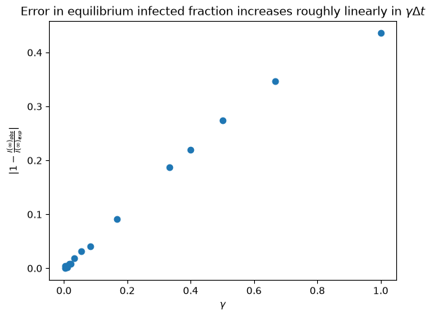

```python
# Validate for each row that mean(recovered / cases) is close to gamma
for idx, row in output.iterrows():
    cases_arr = np.array(row["cases"][0])
    recovered_arr = np.array(row["recovered"][0])
    # Avoid division by zero
    valid = cases_arr > 0
    avg_ratio = np.mean(recovered_arr[valid] / cases_arr[valid])
    print(f"Row {idx}: gamma={row['gamma']:.6f}, avg(recovered/cases)={avg_ratio:.6f}, diff={abs(avg_ratio - row['gamma']):.6f}")
```

# Validate for each row that mean(recovered / cases) is close to gamma for idx, row in output.iterrows(): cases_arr = np.array(row["cases"][0]) recovered_arr = np.array(row["recovered"][0]) # Avoid division by zero valid = cases_arr > 0 avg_ratio = np.mean(recovered_arr[valid] / cases_arr[valid]) print(f"Row {idx}: gamma={row['gamma']:.6f}, avg(recovered/cases)={avg_ratio:.6f}, diff={abs(avg_ratio - row['gamma']):.6f}")

```
Row 0: gamma=0.004783, avg(recovered/cases)=0.004602, diff=0.000181
Row 1: gamma=0.008704, avg(recovered/cases)=0.008458, diff=0.000246
Row 2: gamma=0.004881, avg(recovered/cases)=0.004585, diff=0.000295
Row 3: gamma=0.004713, avg(recovered/cases)=0.004483, diff=0.000230
Row 4: gamma=0.007682, avg(recovered/cases)=0.007355, diff=0.000328
Row 5: gamma=0.008158, avg(recovered/cases)=0.008146, diff=0.000011
Row 6: gamma=0.008644, avg(recovered/cases)=0.008615, diff=0.000029
Row 7: gamma=0.006014, avg(recovered/cases)=0.005965, diff=0.000050
Row 8: gamma=0.004760, avg(recovered/cases)=0.004959, diff=0.000198
Row 9: gamma=0.009030, avg(recovered/cases)=0.008822, diff=0.000207
```

July 10, 2026